```r
library(data.table)
library(dplyr)
```

```r
library(ggplot2)
library(tidyverse)
library(rvest)
library(stringr)
library(DT)
library(tidyr)
library(corrplot)
library(leaflet)
library(lubridate)
library(jsonlite)
library(httr)
library(readr)
library(xgboost)
library(readxl)
library(e1071)
library(caret)
library(caTools)
library(cowplot)
library(pROC)
library(ggcorrplot)
library(corrplot)
library(readxl)
setwd("/Users/brookejackson/Dropbox/Data Science Intensive/Capstone")
```

Playlist Songs: Read in the tracks from the Top 25 and bottom 3 Actively updated, Spotify-Curated, new songs (“Frontline”) playlists:

```r
all = read_csv("alltracks.csv") #train
all <- as_data_frame(all)
current = read_csv("tracks_052920.csv") #test
current <- as.data.frame(current)

followers <- read_csv("playlist_followers2.csv")
```

```r
followers <- as_data_frame(followers)
all <- merge(all, followers, by = "playlist_name") #this could be slightly misleading, because follower numbers are current, and the observations are historical. I've included a 28-day follower percent change in case we need to use this later
current <- merge(current, followers, by = "playlist_name")
which(colnames(all)=="Followers") #check to make sure the followers data moved to the end
```

```
## [1] 51
```

Clean up the dataframe for analysis. Remove all the date variables (not doing a time forecast for this project) and ID-type variables:

```r
colnames(all)
```

```
##  [1] "playlist_name"
##  [2] "X1"
##  [3] "track_id"
##  [4] "ISRC"
##  [5] "Position"
##  [6] "Playlist Add Date"
##  [7] "Playlist Remove Date"
##  [8] "Days In Playlist"
##  [9] "name"
## [10] "Spotify Popularity"
## [11] "Artist(s)"
## [12] "track_genre"
## [13] "Spotify Artist Id(s)"
## [14] "Spotify Track Ids"
## [15] "Spotify Album Ids"
```

[output cut: 39 more lines]

```r
all[,c('X1',"track_id","ISRC","Playlist Add Date", "Spotify Artist Id(s)","Spotify Album Ids", "Album Name", "UPC","Release Date(s)","Spotify Track Link","Spotify Album Link","Spotify Artist Link")] <- NULL
current[,c('X1',"track_id","ISRC","Playlist Add Date", "Spotify Artist Id(s)","Spotify Album Ids", "Album Name", "UPC","Release Date(s)","Spotify Track Link","Spotify Album Link","Spotify Artist Link")] <- NULL
```

Change the column names>

```r
colnames(all) <- c("playlist_name","playlist_position", "in_current_playlist", "days_in_playlist", "song_name", "song_popularity", "artist_name","track_genre","spotify_track_id","record_label","are_&_be","cardio", "chilled_r&b","chill_hits", "dance_rising", "get_turnt", "happy_hits", "hot_country","hot_rhythmic", "intense_study","kpop_daebak","mint","mood_booster", "most_necessary","motivation_mix", "new_music_friday","next_from_nashville","peaceful_piano","popco", "pop_remix","power_workout","rapcaviar","rock_this","silk_sheets","sleep","teen_party","ultimate_indie","workout","playlist_followers","lastmonthfollowerchange_percent","playlist_genres","tracks_in_playlist")
colnames(current) <- c("playlist_name","playlist_position", "days_in_playlist", "song_name", "song_popularity", "artist_name","track_genre","spotify_track_id","record_label","in_current_playlist","are_&_be","cardio", "chilled_r&b","chill_hits", "dance_rising", "get_turnt", "happy_hits", "hot_country","hot_rhythmic", "intense_study","kpop_daebak","mint","mood_booster", "most_necessary","motivation_mix", "new_music_friday","next_from_nashville","peaceful_piano","popco", "pop_remix","power_workout","rapcaviar","rock_this","silk_sheets","sleep","teen_party","ultimate_indie","workout","playlist_followers","lastmonthfollowerchange_percent","playlist_genres","tracks_in_playlist")
colnames(current)
```

```
##  [1] "playlist_name"                   "playlist_position"
##  [3] "days_in_playlist"                "song_name"
##  [5] "song_popularity"                 "artist_name"
##  [7] "track_genre"                     "spotify_track_id"
##  [9] "record_label"                    "in_current_playlist"
## [11] "are_&_be"                        "cardio"
## [13] "chilled_r&b"                     "chill_hits"
## [15] "dance_rising"                    "get_turnt"
## [17] "happy_hits"                      "hot_country"
## [19] "hot_rhythmic"                    "intense_study"
## [21] "kpop_daebak"                     "mint"
## [23] "mood_booster"                    "most_necessary"
## [25] "motivation_mix"                  "new_music_friday"
## [27] "next_from_nashville"             "peaceful_piano"
## [29] "popco"                           "pop_remix"
## [31] "power_workout"                   "rapcaviar"
## [33] "rock_this"                       "silk_sheets"
## [35] "sleep"                           "teen_party"
## [37] "ultimate_indie"                  "workout"
## [39] "playlist_followers"              "lastmonthfollowerchange_percent"
## [41] "playlist_genres"                 "tracks_in_playlist"
```

Create a factor variable for current vs removed songs (1 means it’s in the current playlist (not removed), and 0 means it was in past versions of the playlist):

```r
all$in_current_playlist[is.na(all$in_current_playlist)] <- 1
all$in_current_playlist <- ifelse(all$in_current_playlist==1,1,0)

current$in_current_playlist[is.na(current$in_current_playlist)] <- 1
current$in_current_playlist <- ifelse(current$in_current_playlist==1,1,0)
```

Handle missing values:

Past:

```r
missing_data <- all %>% summarise_all(funs(sum(is.na(.))/n()))
```

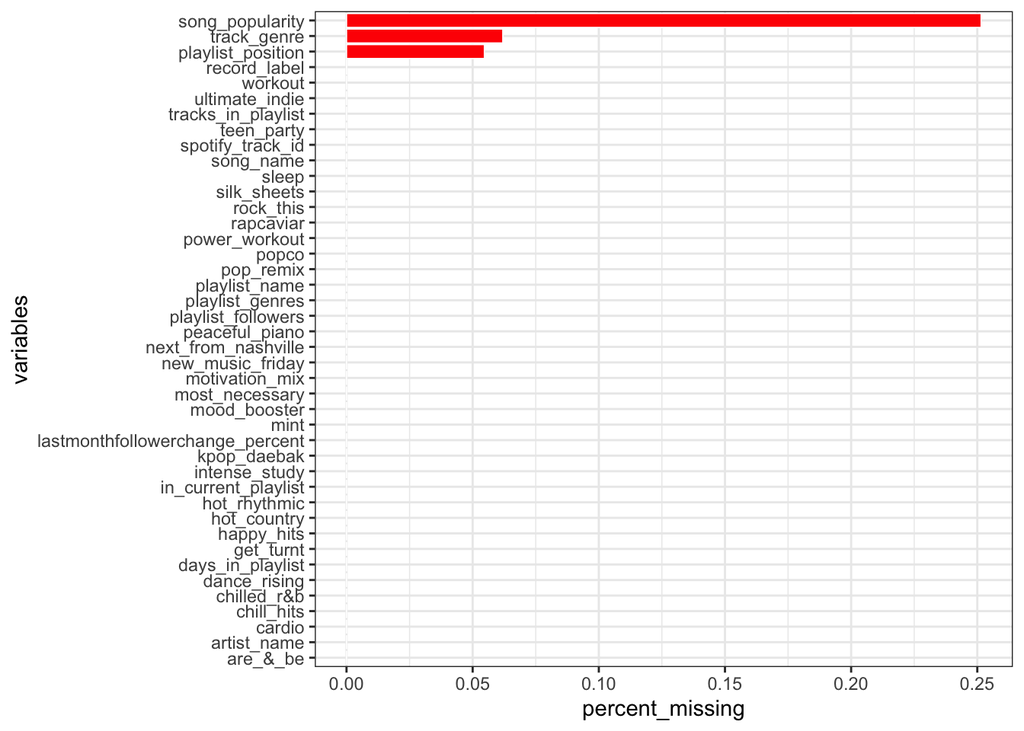

```r
missing_data <- gather(missing_data, key = "variables", value = "percent_missing")
ggplot(missing_data, aes(x = reorder(variables, percent_missing), y = percent_missing)) +
  geom_bar(stat = "identity", fill = "red", aes(color = I('white')), size = 0.3)+
  xlab('variables')+
  coord_flip()+
  theme_bw()
```

```r
all$song_popularity[is.na(all$song_popularity)] <- 0
all$playlist_position[is.na(all$song_popularity)] <- 0
all$track_genre[is.na(all$track_genre)] <- "unknown"
all$record_label[is.na(all$record_label)] <- "none"
library(Hmisc)
```

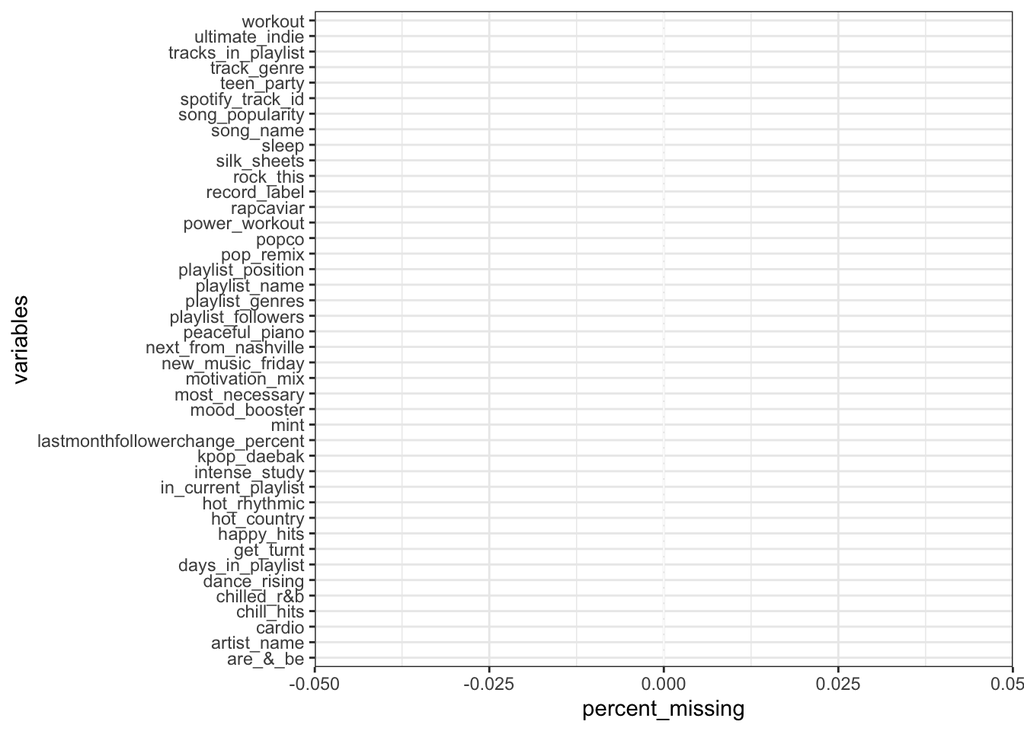

```r
all$playlist_position=impute(all$playlist_position, mean) # replace with mean

missing_data <- all %>% summarise_all(funs(sum(is.na(.))/n()))
missing_data <- gather(missing_data, key = "variables", value = "percent_missing")
ggplot(missing_data, aes(x = reorder(variables, percent_missing), y = percent_missing)) +
  geom_bar(stat = "identity", fill = "red", aes(color = I('white')), size = 0.3)+
  xlab('variables')+
  coord_flip()+
  theme_bw()
```

Current:

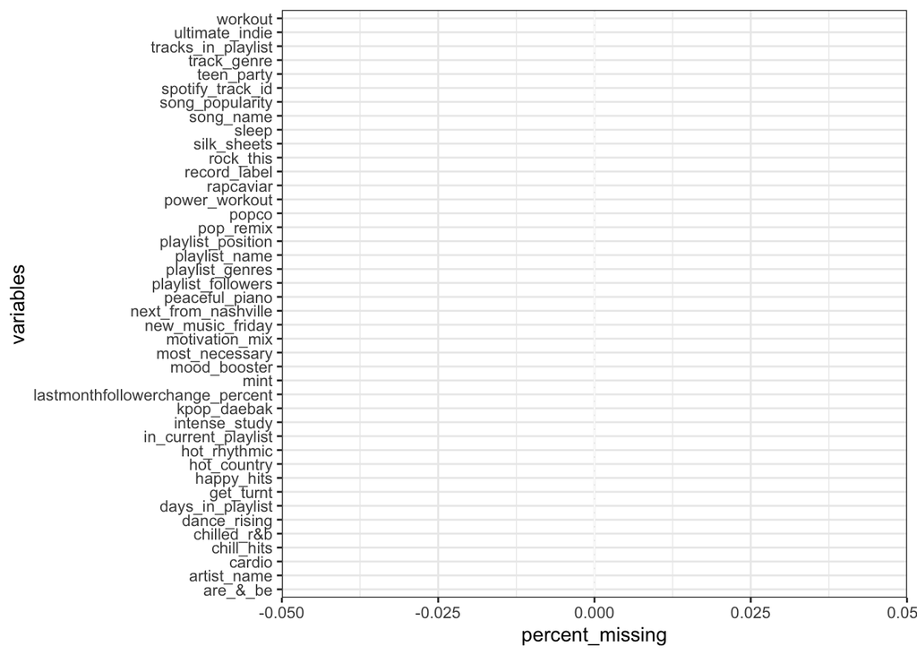

```r
current$song_popularity[is.na(current$song_popularity)] <- 0
current$playlist_position[is.na(current$song_popularity)] <- 0
current$track_genre[is.na(current$track_genre)] <- "unknown"
current$record_label[is.na(current$record_label)] <- "none"
library(Hmisc)
current$playlist_position=impute(current$playlist_position, mean) # replace with mean

missing_datac <- current %>% summarise_all(funs(sum(is.na(.))/n()))
missing_datac <- gather(missing_datac, key = "variables", value = "percent_missing")
ggplot(missing_datac, aes(x = reorder(variables, percent_missing), y = percent_missing)) +
  geom_bar(stat = "identity", fill = "red", aes(color = I('white')), size = 0.3)+
  xlab('variables')+
  coord_flip()+
  theme_bw()
```

Adjust the variables’ classes for analysis:

```r
all$in_current_playlist <- as.factor(all$in_current_playlist)
all$days_in_playlist <- as.integer(all$days_in_playlist)
all$playlist_name <-as.factor(all$playlist_name)

cols <- c("playlist_position","playlist_name","are_&_be","cardio","chilled_r&b","chill_hits","dance_rising","get_turnt","happy_hits","hot_country","hot_rhythmic","intense_study", "kpop_daebak","mint","mood_booster","most_necessary", "motivation_mix", "new_music_friday","next_from_nashville","peaceful_piano","popco","pop_remix","power_workout","rapcaviar","rock_this", "silk_sheets","sleep","teen_party","ultimate_indie","workout")
all[cols] <- lapply(all[cols], factor)
summary(all)
```

```
##         playlist_name          playlist_position in_current_playlist
##  newmusicfriday:18643   50.6193856924518: 5863   0:107278
##  chillhits     : 9194   50              : 2140
##  dancerising   : 8987   60              : 1999
##  cardio        : 8349   49              : 1967
##  motivationmix : 8307   48              : 1890
##  workout       : 7072   59              : 1870
##  (Other)       :46726   (Other)         :91549
##  days_in_playlist  song_name         song_popularity artist_name
##  Min.   :  0.00   Length:107278      Min.   :  0.0   Length:107278
##  1st Qu.:  5.00   Class :character   1st Qu.:  0.0   Class :character
##  Median :  7.00   Mode  :character   Median : 34.0   Mode  :character
##  Mean   : 27.74                      Mean   : 33.1
##  3rd Qu.: 22.00                      3rd Qu.: 58.0
##  Max.   :799.00                      Max.   :100.0
##
##  track_genre        spotify_track_id   record_label       are_&_be   cardio
##  Length:107278      Length:107278      Length:107278      0:106729   0:98929
##  Class :character   Class :character   Class :character   1:   549   1: 8349
##  Mode  :character   Mode  :character   Mode  :character
##
##
##
##
##  chilled_r&b chill_hits dance_rising get_turnt  happy_hits hot_country
##  0:106809    0:98084    0:98291      0:103551   0:100982   0:106483
##  1:   469    1: 9194    1: 8987      1:  3727   1:  6296   1:   795
##
##
##
##
##
##  hot_rhythmic intense_study kpop_daebak mint       mood_booster most_necessary
##  0:105084     0:105911      0:106354    0:102617   0:106086     0:104812
##  1:  2194     1:  1367      1:   924    1:  4661   1:  1192     1:  2466
##
##
##
##
##
```

[output cut: 17 more lines]

```
##  0:102038   0:106211       0:100206   Min.   :   84998
##  1:  5240   1:  1067       1:  7072   1st Qu.: 2947114
##                                       Median : 3725217
##                                       Mean   : 4053852
##                                       3rd Qu.: 5426272
##                                       Max.   :12970351
##
##  lastmonthfollowerchange_percent playlist_genres    tracks_in_playlist
##  Min.   :-0.3057                 Length:107278      Min.   : 46.00
##  1st Qu.: 0.2146                 Class :character   1st Qu.: 60.00
##  Median : 0.6930                 Mode  :character   Median : 97.00
##  Mean   : 0.7180                                    Mean   : 97.86
##  3rd Qu.: 0.9750                                    3rd Qu.:100.00
##  Max.   : 2.9314                                    Max.   :266.00
##
```

```r
str(all)
```

```
## 'data.frame':    107278 obs. of  42 variables:
##  $ playlist_name                  : Factor w/ 28 levels "arebe","cardio",..: 1 1 1 1 1 1 1 1 1 1 ...
##  $ playlist_position              : Factor w/ 270 levels "1","2","3","4",..: 32 3 9 23 34 35 43 45 12 35 ...
##  $ in_current_playlist            : Factor w/ 1 level "0": 1 1 1 1 1 1 1 1 1 1 ...
##  $ days_in_playlist               : int  48 63 229 126 132 133 217 79 11 49 ...
##  $ song_name                      : chr  "Touchy Feely" "Between Us (feat. Snoh Aalegra)" "Playing Games (with Bryson Tiller) - Extended Version" "Slide (feat. Pop Smoke) - Remix" ...
##  $ song_popularity                : num  0 0 78 0 0 0 0 0 0 59 ...
##  $ artist_name                    : chr  "Ro James" "dvsn, Snoh Aalegra" "Summer Walker, Bryson Tiller" "H.E.R., A Boogie Wit da Hoodie, Chris Brown" ...
##  $ track_genre                    : chr  "alternative r&b,deep pop r&b,indie r&b,r&b" "alternative r&b,canadian contemporary r&b,deep pop r&b,indie r&b,pop,r&b,rap,trap soul,alternative r&b,indie r&"| __truncated__ "pop,pop rap,rap,trap,pop,pop rap" "dance pop,pop,pop rap,r&b,rap,melodic rap,rap,…
##  $ spotify_track_id               : chr  "2Ydl4YxqE82OD3A1LGFWBc" "2ynqtdm2zE73wuNKjGItwp" "2xyx0o4xNOLLjBSbOOdcbA" "6MO2bfLHKykUgCChFdw91H" ...
##  $ record_label                   : chr  "ByStorm Entertainment/RCA Records" "OVO Sound/Warner Records" "LVRN/Interscope Records" "MBK Entertainment/RCA Records" ...
##  $ are_&_be                       : Factor w/ 2 levels "0","1": 2 2 2 2 2 2 2 2 2 2 ...
##  $ cardio                         : Factor w/ 2 levels "0","1": 1 1 1 1 1 1 1 1 1 1 ...
##  $ chilled_r&b                    : Factor w/ 2 levels "0","1": 1 1 1 1 1 1 1 1 1 1 ...
##  $ chill_hits                     : Factor w/ 2 levels "0","1": 1 1 1 1 1 1 1 1 1 1 ...
```

[output cut: 28 more lines]

```r
all <-as.data.frame(all)

current$in_current_playlist <- as.factor(current$in_current_playlist)
current$days_in_playlist <- as.integer(current$days_in_playlist)
current$playlist_name <-as.factor(current$playlist_name)

colsc <- c("playlist_position","playlist_name","are_&_be","cardio","chilled_r&b","chill_hits","dance_rising","get_turnt","happy_hits","hot_country","hot_rhythmic","intense_study", "kpop_daebak","mint","mood_booster","most_necessary", "motivation_mix", "new_music_friday","next_from_nashville","peaceful_piano","popco","pop_remix","power_workout","rapcaviar","rock_this", "silk_sheets","sleep","teen_party","ultimate_indie","workout")
current[colsc] <- lapply(current[colsc], factor)
```

Song Audio Features: Read in the audio features dataframe for each of the songs in the playlists. (extracted using Spotify’s Spotipy developer API in Python, and exported to csv)

```r
setwd("/Users/brookejackson/Dropbox/Data Science Intensive/Capstone/top_spotify_playlists_history")
rc <- read_csv("rapcaviarfeatures.csv")
rc[,1] <- NULL
colnames(rc) <- c("qualities")
hc <- read_csv("hotcountryfeatures.csv")
hc[,1] <- NULL
colnames(hc) <- c("qualities")
pp <- read_csv("peacefulpianofeatures.csv")
pp[,1] <- NULL
colnames(pp) <- c("qualities")
gt <- read_csv("getturntfeatures.csv")
gt[,1] <- NULL
colnames(gt) <- c("qualities")
ss <- read_csv("silksheetsfeatures.csv")
ss[,1] <- NULL
colnames(ss) <- c("qualities")
nn <- read_csv("nextnashfeatures.csv")
nn[,1] <- NULL
colnames(nn) <- c("qualities")
pc <- read_csv("popcofeatures.csv")
pc[,1] <- NULL
colnames(pc) <- c("qualities")
crb <- read_csv("chilledrbfeatures.csv")
crb[,1] <- NULL
colnames(crb) <- c("qualities")
hr <- read_csv("hotrhythmicfeatures.csv")
hr[,1] <- NULL
colnames(hr) <- c("qualities")
ui  <- read_csv("ultindiefeatures.csv")
ui[,1] <- NULL
colnames(ui) <- c("qualities")
is <- read_csv("intensestudyfeatures.csv")
is[,1] <- NULL
colnames(is) <- c("qualities")
mn <- read_csv("mostnecessaryfeatures.csv")
mn[,1] <- NULL
colnames(mn) <- c("qualities")
kp <- read_csv("kpopdaebakfeatures.csv")
kp[,1] <- NULL
colnames(kp) <- c("qualities")
c <- read_csv("cardiofeatures.csv")
c[,1] <- NULL
colnames(c) <- c("qualities")
pr <- read_csv("popremixfeatures.csv")
pr[,1] <- NULL
colnames(pr) <- c("qualities")
pwo <- read_csv("powerworkoutfeatures.csv")
pwo[,1] <- NULL
colnames(pwo) <- c("qualities")
nmf  <- read_csv("newmusicfridayfeatures.csv")
nmf[,1] <- NULL
colnames(nmf) <- c("qualities")
wo <- read_csv("workoutfeatures.csv")
wo[,1] <- NULL
colnames(wo) <- c("qualities")
s <- read.csv("sleepfeatures.csv")
s[,1] <- NULL
colnames(s) <- c("qualities")
tp <- read.csv("teenpartyfeatures.csv")
tp[,1] <- NULL
colnames(tp) <- c("qualities")
rt <- read.csv("rockthisfeatures.csv")
rt[,1] <- NULL
colnames(rt) <- c("qualities")
mm <- read.csv("motivationmixfeatures.csv")
mm[,1] <- NULL
colnames(mm) <- c("qualities")
ab <- read.csv("arebefeatures.csv")
ab[,1] <- NULL
colnames(ab) <- c("qualities")
mb <- read.csv("moodboosterfeatures.csv")
mb[,1] <- NULL
colnames(mb) <- c("qualities")
hh <- read.csv("happyhitsfeatures.csv")
hh[,1] <- NULL
colnames(hh) <- c("qualities")
m <- read.csv("mintfeatures.csv")
m[,1] <- NULL
colnames(m) <- c("qualities")
ch <- read.csv("chillhitsfeatures.csv")
ch[,1] <- NULL
colnames(ch) <- c("qualities")
dr <- read.csv("dancerisingfeatures.csv")
dr[,1] <- NULL
colnames(dr) <- c("qualities")

setwd("/Users/brookejackson/Dropbox/Data Science Intensive/Capstone")
```

Make all the variables a dataframe:

```r
features <- rbind(rc,hc,pp,gt,ss,nn,pc,crb,hr,ui,is,mn,kp,c,pr,pwo,nmf,wo,s,tp,rt,mm,ab,mb,hh,m,ch,dr)
str(features)
```

```
## tibble [107,278 × 1] (S3: spec_tbl_df/tbl_df/tbl/data.frame)
##  $ qualities: chr [1:107278] "{'danceability': 0.929, 'energy': 0.7, 'key': 0, 'loudness': -5.595, 'mode': 0, 'speechiness': 0.0906, 'acousti"| __truncated__ "{'danceability': 0.883, 'energy': 0.808, 'key': 1, 'loudness': -3.158, 'mode': 0, 'speechiness': 0.183, 'acoust"| __truncated__ "{'danceab…
##  - attr(*, "spec")=
##   .. cols(
##   ..   X1 = col_double(),
##   ..   `0` = col_character()
##   .. )
```

```r
features <- as.data.frame(features)
remove(rc,hc,pp,gt,ss,nn,pc,crb,hr,ui,is,mn,kp,c,pr,pwo,nmf,wo,s,tp,rt,mm,ab,mb,hh,m,ch,dr)
```

Clean up the features dataframe for analysis:

```r
library(splitstackshape)
features <- cSplit(features,'qualities',sep=", ")
colnames(features)
```

```
##  [1] "qualities_01" "qualities_02" "qualities_03" "qualities_04" "qualities_05"
##  [6] "qualities_06" "qualities_07" "qualities_08" "qualities_09" "qualities_10"
## [11] "qualities_11" "qualities_12" "qualities_13" "qualities_14" "qualities_15"
## [16] "qualities_16" "qualities_17" "qualities_18"
```

```r
features <- cSplit(features, splitCols = 1:18,sep = ": ", drop=TRUE)
print(colnames(features))
```

```
##  [1] "qualities_01_1" "qualities_01_2" "qualities_02_1" "qualities_02_2"
##  [5] "qualities_03_1" "qualities_03_2" "qualities_04_1" "qualities_04_2"
##  [9] "qualities_05_1" "qualities_05_2" "qualities_06_1" "qualities_06_2"
## [13] "qualities_07_1" "qualities_07_2" "qualities_08_1" "qualities_08_2"
## [17] "qualities_09_1" "qualities_09_2" "qualities_10_1" "qualities_10_2"
## [21] "qualities_11_1" "qualities_11_2" "qualities_12_1" "qualities_12_2"
## [25] "qualities_13_1" "qualities_13_2" "qualities_14_1" "qualities_14_2"
## [29] "qualities_15_1" "qualities_15_2" "qualities_16_1" "qualities_16_2"
## [33] "qualities_17_1" "qualities_17_2" "qualities_18_1" "qualities_18_2"
```

```r
head(features)
```

```
##     qualities_01_1 qualities_01_2 qualities_02_1 qualities_02_2 qualities_03_1
## 1: {'danceability'          0.929       'energy'          0.700          'key'
## 2: {'danceability'          0.883       'energy'          0.808          'key'
## 3: {'danceability'          0.788       'energy'          0.436          'key'
## 4: {'danceability'          0.819       'energy'          0.654          'key'
## 5: {'danceability'          0.855       'energy'          0.676          'key'
## 6: {'danceability'          0.802       'energy'          0.737          'key'
##    qualities_03_2 qualities_04_1 qualities_04_2 qualities_05_1 qualities_05_2
## 1:              0     'loudness'         -5.595         'mode'              0
## 2:              1     'loudness'         -3.158         'mode'              0
## 3:              1     'loudness'         -9.435         'mode'              1
## 4:             11     'loudness'         -6.665         'mode'              0
## 5:              1     'loudness'         -5.736         'mode'              1
## 6:              6     'loudness'         -4.862         'mode'              0
##    qualities_06_1 qualities_06_2 qualities_07_1 qualities_07_2
```

[output cut: 55 more lines]

```r
features[ ,c("qualities_01_1","qualities_02_1", "qualities_03_1", "qualities_04_1","qualities_05_1","qualities_06_1","qualities_07_1","qualities_08_1","qualities_09_1","qualities_10_1","qualities_11_1","qualities_12_1","qualities_12_2","qualities_13_1","qualities_14_1","qualities_14_2","qualities_15_1","qualities_15_2","qualities_16_1","qualities_16_2","qualities_17_1","qualities_18_1")] <- NULL
colnames(features) = c("danceability","energy","key","loudness","mode","speechiness","acousticness","instrumentalness","liveness","valence","tempo","spotify_track_id","duration_ms","time_signature")
features$time_signature <- gsub("}","",features$time_signature)
features$spotify_track_id <- gsub("'","",features$spotify_track_id)
```

Adjust the variables’ classes:

```r
features$key <- as.factor(features$key)
features$mode <- as.factor(features$mode)
features$spotify_track_id <- as.character(features$spotify_track_id)
features$time_signature <- as.factor(features$time_signature)
features$tempo <- as.integer(features$tempo)
```

Sort the columns:

```r
features <- features[,c("spotify_track_id","danceability", "energy","key","loudness","mode","speechiness","acousticness","instrumentalness","liveness","valence","tempo","duration_ms","time_signature")]
```

Narrow down the features for the unique tracks only:

```r
unique <- unique(features)
```

Join the dataframe of songs with with dataframe of their audio features

```r
pastplaylists <- left_join(all,unique,by="spotify_track_id")
str(pastplaylists)
```

```
## 'data.frame':    107289 obs. of  55 variables:
##  $ playlist_name                  : Factor w/ 28 levels "arebe","cardio",..: 1 1 1 1 1 1 1 1 1 1 ...
##  $ playlist_position              : Factor w/ 270 levels "1","2","3","4",..: 32 3 9 23 34 35 43 45 12 35 ...
##  $ in_current_playlist            : Factor w/ 1 level "0": 1 1 1 1 1 1 1 1 1 1 ...
##  $ days_in_playlist               : int  48 63 229 126 132 133 217 79 11 49 ...
##  $ song_name                      : chr  "Touchy Feely" "Between Us (feat. Snoh Aalegra)" "Playing Games (with Bryson Tiller) - Extended Version" "Slide (feat. Pop Smoke) - Remix" ...
##  $ song_popularity                : num  0 0 78 0 0 0 0 0 0 59 ...
##  $ artist_name                    : chr  "Ro James" "dvsn, Snoh Aalegra" "Summer Walker, Bryson Tiller" "H.E.R., A Boogie Wit da Hoodie, Chris Brown" ...
##  $ track_genre                    : chr  "alternative r&b,deep pop r&b,indie r&b,r&b" "alternative r&b,canadian contemporary r&b,deep pop r&b,indie r&b,pop,r&b,rap,trap soul,alternative r&b,indie r&"| __truncated__ "pop,pop rap,rap,trap,pop,pop rap" "dance pop,pop,pop rap,r&b,rap,melodic rap,rap,…
##  $ spotify_track_id               : chr  "2Ydl4YxqE82OD3A1LGFWBc" "2ynqtdm2zE73wuNKjGItwp" "2xyx0o4xNOLLjBSbOOdcbA" "6MO2bfLHKykUgCChFdw91H" ...
##  $ record_label                   : chr  "ByStorm Entertainment/RCA Records" "OVO Sound/Warner Records" "LVRN/Interscope Records" "MBK Entertainment/RCA Records" ...
##  $ are_&_be                       : Factor w/ 2 levels "0","1": 2 2 2 2 2 2 2 2 2 2 ...
##  $ cardio                         : Factor w/ 2 levels "0","1": 1 1 1 1 1 1 1 1 1 1 ...
##  $ chilled_r&b                    : Factor w/ 2 levels "0","1": 1 1 1 1 1 1 1 1 1 1 ...
##  $ chill_hits                     : Factor w/ 2 levels "0","1": 1 1 1 1 1 1 1 1 1 1 ...
```

[output cut: 41 more lines]

Current week: Read in the features data (extracted in Spotify’s Spotipy developer API) for the current week’s playlist tracks (May 29,2020)

```r
setwd("/Users/brookejackson/Dropbox/Data Science Intensive/Capstone")
currenttrackfeatures <- read.csv("currenttracksfeatures.csv")
currenttrackfeatures[,1] <- NULL
colnames(currenttrackfeatures) <- c("qualities")
```

Clean up the features dataframe for analysis:

```r
currenttrackfeatures <- cSplit(currenttrackfeatures,'qualities',sep=", ")
colnames(currenttrackfeatures)
```

```
##  [1] "qualities_01" "qualities_02" "qualities_03" "qualities_04" "qualities_05"
##  [6] "qualities_06" "qualities_07" "qualities_08" "qualities_09" "qualities_10"
## [11] "qualities_11" "qualities_12" "qualities_13" "qualities_14" "qualities_15"
## [16] "qualities_16" "qualities_17" "qualities_18"
```

```r
currenttrackfeatures <- cSplit(currenttrackfeatures, splitCols = 1:18,sep = ": ", drop=TRUE)
print(colnames(currenttrackfeatures))
```

```
##  [1] "qualities_01_1" "qualities_01_2" "qualities_02_1" "qualities_02_2"
##  [5] "qualities_03_1" "qualities_03_2" "qualities_04_1" "qualities_04_2"
##  [9] "qualities_05_1" "qualities_05_2" "qualities_06_1" "qualities_06_2"
## [13] "qualities_07_1" "qualities_07_2" "qualities_08_1" "qualities_08_2"
## [17] "qualities_09_1" "qualities_09_2" "qualities_10_1" "qualities_10_2"
## [21] "qualities_11_1" "qualities_11_2" "qualities_12_1" "qualities_12_2"
## [25] "qualities_13_1" "qualities_13_2" "qualities_14_1" "qualities_14_2"
## [29] "qualities_15_1" "qualities_15_2" "qualities_16_1" "qualities_16_2"
## [33] "qualities_17_1" "qualities_17_2" "qualities_18_1" "qualities_18_2"
```

```r
head(currenttrackfeatures)
```

```
##     qualities_01_1 qualities_01_2 qualities_02_1 qualities_02_2 qualities_03_1
## 1: {'danceability'          0.609       'energy'          0.757          'key'
## 2: {'danceability'          0.752       'energy'          0.673          'key'
## 3: {'danceability'          0.784       'energy'          0.632          'key'
## 4: {'danceability'          0.902       'energy'          0.706          'key'
## 5: {'danceability'          0.844       'energy'          0.616          'key'
## 6: {'danceability'          0.735       'energy'          0.449          'key'
##    qualities_03_2 qualities_04_1 qualities_04_2 qualities_05_1 qualities_05_2
## 1:              2     'loudness'         -5.605         'mode'              1
## 2:             10     'loudness'         -5.792         'mode'              0
## 3:             10     'loudness'         -6.083         'mode'              0
## 4:              8     'loudness'         -4.643         'mode'              0
## 5:              1     'loudness'         -5.200         'mode'              1
## 6:             10     'loudness'         -7.507         'mode'              1
##    qualities_06_1 qualities_06_2 qualities_07_1 qualities_07_2
```

[output cut: 55 more lines]

```r
colnames(currenttrackfeatures)
```

```
##  [1] "qualities_01_1" "qualities_01_2" "qualities_02_1" "qualities_02_2"
##  [5] "qualities_03_1" "qualities_03_2" "qualities_04_1" "qualities_04_2"
##  [9] "qualities_05_1" "qualities_05_2" "qualities_06_1" "qualities_06_2"
## [13] "qualities_07_1" "qualities_07_2" "qualities_08_1" "qualities_08_2"
## [17] "qualities_09_1" "qualities_09_2" "qualities_10_1" "qualities_10_2"
## [21] "qualities_11_1" "qualities_11_2" "qualities_12_1" "qualities_12_2"
## [25] "qualities_13_1" "qualities_13_2" "qualities_14_1" "qualities_14_2"
## [29] "qualities_15_1" "qualities_15_2" "qualities_16_1" "qualities_16_2"
## [33] "qualities_17_1" "qualities_17_2" "qualities_18_1" "qualities_18_2"
```

```r
currenttrackfeatures[ ,c("qualities_01_1","qualities_02_1", "qualities_03_1", "qualities_04_1","qualities_05_1","qualities_06_1","qualities_07_1","qualities_08_1","qualities_09_1","qualities_10_1","qualities_11_1","qualities_12_1","qualities_12_2","qualities_13_1","qualities_14_1","qualities_14_2","qualities_15_1","qualities_15_2","qualities_16_1","qualities_16_2","qualities_17_1","qualities_18_1")] <- NULL
colnames(currenttrackfeatures) = c("danceability","energy","key","loudness","mode","speechiness","acousticness","instrumentalness","liveness","valence","tempo","spotify_track_id","duration_ms","time_signature")
currenttrackfeatures$time_signature <- gsub("}","",currenttrackfeatures$time_signature)
currenttrackfeatures$spotify_track_id <- gsub("'","",currenttrackfeatures$spotify_track_id)
head(currenttrackfeatures)
```

```
##    danceability energy key loudness mode speechiness acousticness
## 1:        0.609  0.757   2   -5.605    1       0.119       0.2990
## 2:        0.752  0.673  10   -5.792    0       0.153       0.0538
## 3:        0.784  0.632  10   -6.083    0       0.347       0.1560
## 4:        0.902  0.706   8   -4.643    0       0.204       0.0459
## 5:        0.844  0.616   1   -5.200    1       0.161       0.0084
## 6:        0.735  0.449  10   -7.507    1       0.347       0.6290
##    instrumentalness liveness valence   tempo       spotify_track_id duration_ms
## 1:          0.0e+00   0.6300  0.3790 128.022 4CNcRgjGw1v9VQaTaytdnD      180129
## 2:          0.0e+00   0.1330  0.3500 164.009 2QqJTIlGKRLJC3onkavYEz      163902
## 3:          0.0e+00   0.6050  0.7460 124.603 0gO3E51A3fqp0ypJ26QbVP      232839
## 4:          2.5e-06   0.0682  0.9550  98.034 2z4eJOcmzeopzffNpor4vt      168202
## 5:          0.0e+00   0.1210  0.1880 160.024 34xlXbZ4Ws3GGpUKeimDu5      180753
## 6:          0.0e+00   0.1130  0.0397 122.947 4wVOKKEHUJxHCFFNUWDn0B      220488
##    time_signature
## 1:              4
## 2:              4
## 3:              4
## 4:              4
## 5:              4
## 6:              4
```

Adjust the variables’ classes:

```r
currenttrackfeatures$key <- as.factor(currenttrackfeatures$key)
currenttrackfeatures$mode <- as.factor(currenttrackfeatures$mode)
currenttrackfeatures$spotify_track_id <- as.character(currenttrackfeatures$spotify_track_id)
currenttrackfeatures$time_signature <- as.factor(currenttrackfeatures$time_signature)
currenttrackfeatures$tempo <- as.integer(currenttrackfeatures$tempo)
```

Sort the columns, narrow down the features for the unique tracks only, and join the dataframe of songs with with dataframe of their audio features.

```r
currenttrackfeatures <- currenttrackfeatures[,c("spotify_track_id","danceability", "energy","key","loudness","mode","speechiness","acousticness","instrumentalness","liveness","valence","tempo","duration_ms","time_signature")]

uniquec <- unique(currenttrackfeatures)

currentplaylists <- left_join(current,uniquec,by="spotify_track_id")
```

1. Exploratory Data Analysis:

Visualize the historical playlists by songs’ audio features, and calculate the features by playlist group.

```r
mean_danceability = aggregate(danceability~playlist_name, pastplaylists,mean)
mean_energy = aggregate(energy~playlist_name, pastplaylists,mean)
mean_speechiness = aggregate(speechiness~playlist_name, pastplaylists,mean)
mean_acousticness = aggregate(acousticness~playlist_name, pastplaylists,mean)
mean_instrumentalness = aggregate(instrumentalness~playlist_name,pastplaylists,mean)
mean_liveness = aggregate(liveness~playlist_name,pastplaylists,mean)
mean_valence = aggregate(valence~playlist_name,pastplaylists,mean)
mean_tempo = aggregate(tempo~playlist_name,pastplaylists,mean)
mean_duration = aggregate(duration_ms~playlist_name,pastplaylists,mean)
mean_loudness = aggregate(loudness~playlist_name, pastplaylists,mean)


mode_function <- function(x) {
  mode0 <- names(which.max(table(x)))
  if(is.numeric(x)) return(as.numeric(mode0))
  mode0
}
mode_key =  aggregate(key~playlist_name,data=pastplaylists,FUN=mode_function)
mode_mode =  aggregate(mode~playlist_name,data=pastplaylists,FUN=mode_function)
mode_time_signature = aggregate(time_signature~playlist_name,data=pastplaylists,FUN=mode_function)
```

2. Visualization (simple) Pull the features csv into Tableau for better visualization.

```r
featuresviz <- left_join(mean_danceability,mean_valence)
featuresviz <- left_join(featuresviz,mean_acousticness)
featuresviz <- left_join(featuresviz,mean_energy)
featuresviz <- left_join(featuresviz,mean_instrumentalness)
featuresviz <- left_join(featuresviz,mean_liveness)
featuresviz <- left_join(featuresviz,mean_loudness)
featuresviz <- left_join(featuresviz,mean_speechiness)
featuresviz <- left_join(featuresviz,mean_tempo)
featuresviz <- left_join(featuresviz,mean_valence)
featuresviz <- left_join(featuresviz,mean_duration)
featuresviz <- left_join(featuresviz,mode_key)
featuresviz <- left_join(featuresviz,mode_mode)
featuresviz <- left_join(featuresviz,mode_time_signature)
str(featuresviz)
```

```
## 'data.frame':    28 obs. of  14 variables:
##  $ playlist_name   : Factor w/ 28 levels "arebe","cardio",..: 1 2 3 4 5 6 7 8 9 10 ...
##  $ danceability    : num  0.632 0.669 0.612 0.634 0.653 ...
##  $ valence         : num  0.43 0.487 0.4 0.428 0.397 ...
##  $ acousticness    : num  0.2572 0.0823 0.3337 0.3734 0.0603 ...
##  $ energy          : num  0.571 0.789 0.523 0.506 0.83 ...
##  $ instrumentalness: num  0.00658 0.00639 0.01076 0.00568 0.25244 ...
##  $ liveness        : num  0.163 0.197 0.151 0.156 0.207 ...
##  $ loudness        : num  -7.12 -4.75 -7.73 -7.72 -5.33 ...
##  $ speechiness     : num  0.1383 0.0751 0.121 0.077 0.0789 ...
##  $ tempo           : num  113 121 112 116 125 ...
##  $ duration_ms     : num  225531 193800 227611 197416 206212 ...
##  $ key             : chr  "1" "1" "1" "0" ...
##  $ mode            : chr  "0" "1" "0" "1" ...
##  $ time_signature  : chr  "4" "4" "4" "4" ...
```

```r
featuresviz$key <- as.factor(featuresviz$key)
featuresviz$mode <- as.factor(featuresviz$mode)
featuresviz$time_signature <- as.factor(featuresviz$time_signature)
#Export to csv for better visualization using Tableau
write_csv(featuresviz,"viz.csv")
```

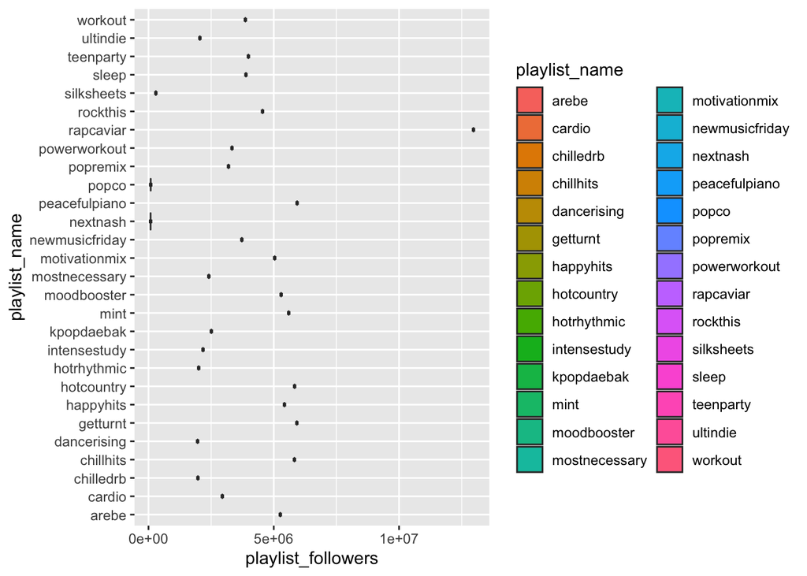

```r
ggplot(pastplaylists, aes(x=playlist_followers, y=playlist_name, fill=playlist_name)) + geom_violin()+
  geom_boxplot(width=0.2, fill="lightblue")
```

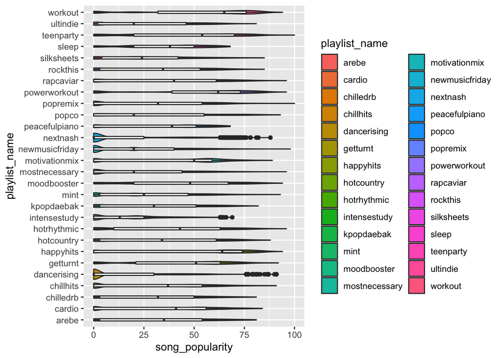

```r
ggplot(pastplaylists, aes(x=song_popularity, y=playlist_name, fill=playlist_name)) + geom_violin()+
  geom_boxplot(width=0.2, fill="white")
```

3. Correlation Correlate audio features from the playlist tracks:

```r
str(featuresviz)
```

```
## 'data.frame':    28 obs. of  14 variables:
##  $ playlist_name   : Factor w/ 28 levels "arebe","cardio",..: 1 2 3 4 5 6 7 8 9 10 ...
##  $ danceability    : num  0.632 0.669 0.612 0.634 0.653 ...
##  $ valence         : num  0.43 0.487 0.4 0.428 0.397 ...
##  $ acousticness    : num  0.2572 0.0823 0.3337 0.3734 0.0603 ...
##  $ energy          : num  0.571 0.789 0.523 0.506 0.83 ...
##  $ instrumentalness: num  0.00658 0.00639 0.01076 0.00568 0.25244 ...
##  $ liveness        : num  0.163 0.197 0.151 0.156 0.207 ...
##  $ loudness        : num  -7.12 -4.75 -7.73 -7.72 -5.33 ...
##  $ speechiness     : num  0.1383 0.0751 0.121 0.077 0.0789 ...
##  $ tempo           : num  113 121 112 116 125 ...
##  $ duration_ms     : num  225531 193800 227611 197416 206212 ...
##  $ key             : Factor w/ 6 levels "0","1","11","2",..: 2 2 2 1 2 2 1 1 2 6 ...
##  $ mode            : Factor w/ 2 levels "0","1": 1 2 1 2 2 2 2 2 2 2 ...
##  $ time_signature  : Factor w/ 1 level "4": 1 1 1 1 1 1 1 1 1 1 ...
```

```r
cor_num <-featuresviz[, c(2:11)]
cor_num
```

```
##    danceability   valence acousticness     energy instrumentalness  liveness
## 1     0.6315574 0.4302699   0.25716405 0.57100911     0.0065820777 0.1630944
## 2     0.6691079 0.4873016   0.08229392 0.78918625     0.0063945147 0.1970020
## 3     0.6117399 0.4000955   0.33372165 0.52341365     0.0107608749 0.1509953
## 4     0.6335857 0.4275800   0.37339118 0.50592729     0.0056776068 0.1555889
## 5     0.6533569 0.3965924   0.06027625 0.83042566     0.2524371376 0.2071832
## 6     0.7714512 0.4515735   0.12114673 0.62709765     0.0027968156 0.1898563
## 7     0.6679292 0.5633369   0.14677269 0.72836674     0.0018944518 0.1723929
## 8     0.5657660 0.5393991   0.16259575 0.73160692     0.0022432036 0.1577616
## 9     0.7045014 0.4672884   0.16828049 0.64712990     0.0082099000 0.1729292
## 10    0.3438878 0.2663616   0.95779473 0.11374125     0.8005941048 0.1286156
## 11    0.6485833 0.5674381   0.21246491 0.76466667     0.0004690848 0.2114253
## 12    0.6171094 0.3797931   0.07316620 0.81648851     0.1968072950 0.2176577
## 13    0.6654690 0.5098031   0.15348769 0.68614346     0.0071762711 0.1735058
## 14    0.7661472 0.4639054   0.16572458 0.60962981     0.0029985729 0.1669871
```

[output cut: 43 more lines]

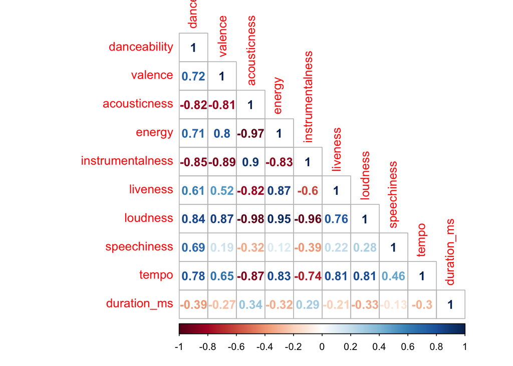

```r
corrplot(cor(cor_num, use="complete.obs"), type="lower", method="number")
```

Loudness is highly correlated with most of the features, and almost perfectly negatively correlated with acousticness and instrumentalness. (We may not need this feature included?) Acousticness is almost perfectly inverse to energy Instrumentalness is negatively correlated with danceability Takeaway: For regression analysis, don’t recommending using Loudness or Acousticness, since those are both highly positively and negatively correlated with the other features and we may see multi-colinearity

4. Simple Linear Regressions

Regression #1: #Song popularity as explained by the Playlist

```r
fit01 = lm(song_popularity~playlist_name,pastplaylists)
summary(fit01)
```

```
##
## Call:
## lm(formula = song_popularity ~ playlist_name, data = pastplaylists)
##
## Residuals:
##     Min      1Q  Median      3Q     Max
## -53.093 -22.167   2.959  21.187  75.877
##
## Coefficients:
##                             Estimate Std. Error t value Pr(>|t|)
## (Intercept)                  32.9545     1.0996  29.970  < 2e-16 ***
## playlist_namecardio           1.8581     1.1351   1.637  0.10166
## playlist_namechilledrb       -2.3447     1.6200  -1.447  0.14781
## playlist_namechillhits       -2.5388     1.1319  -2.243  0.02491 *
## playlist_namedancerising    -17.8314     1.1326 -15.743  < 2e-16 ***
## playlist_namegetturnt        10.7049     1.1778   9.089  < 2e-16 ***
## playlist_namehappyhits       15.0228     1.1465  13.103  < 2e-16 ***
## playlist_namehotcountry       0.7864     1.4297   0.550  0.58227
## playlist_namehotrhythmic      5.6134     1.2295   4.566 4.98e-06 ***
## playlist_nameintensestudy   -16.8872     1.3018 -12.972  < 2e-16 ***
## playlist_namekpopdaebak      -2.8820     1.3883  -2.076  0.03791 *
## playlist_namemint            -4.7692     1.1625  -4.103 4.09e-05 ***
## playlist_namemoodbooster      9.4121     1.3289   7.083 1.42e-12 ***
## playlist_namemostnecessary   -9.4849     1.2158  -7.801 6.19e-15 ***
## playlist_namemotivationmix    5.8159     1.1353   5.123 3.02e-07 ***
## playlist_namenewmusicfriday -10.7877     1.1156  -9.670  < 2e-16 ***
## playlist_namenextnash       -18.1271     1.2768 -14.197  < 2e-16 ***
## playlist_namepeacefulpiano   -2.3065     1.4204  -1.624  0.10442
## playlist_namepopco           -2.3738     1.7301  -1.372  0.17005
## playlist_namepopremix        -3.5496     1.1682  -3.039  0.00238 **
## playlist_namepowerworkout    19.0864     1.1565  16.504  < 2e-16 ***
## playlist_namerapcaviar        1.5334     1.2590   1.218  0.22326
## playlist_namerockthis        -1.5975     1.4368  -1.112  0.26621
## playlist_namesilksheets      -6.4412     1.6363  -3.936 8.28e-05 ***
## playlist_namesleep            2.2891     1.5322   1.494  0.13517
## playlist_nameteenparty       11.8795     1.1557  10.279  < 2e-16 ***
## playlist_nameultindie        -6.1672     1.3532  -4.558 5.18e-06 ***
## playlist_nameworkout         20.1382     1.1415  17.643  < 2e-16 ***
## ---
## Signif. codes:  0 '***' 0.001 '**' 0.01 '*' 0.05 '.' 0.1 ' ' 1
##
## Residual standard error: 25.76 on 107261 degrees of freedom
## Multiple R-squared:  0.1671, Adjusted R-squared:  0.1669
## F-statistic:   797 on 27 and 107261 DF,  p-value: < 2.2e-16
```

Regression #2: y (dependent) = Days in playlist x (independent) = Playlist

```r
fit02 = lm(days_in_playlist~playlist_name, pastplaylists)
summary(fit02)
```

```
##
## Call:
## lm(formula = days_in_playlist ~ playlist_name, data = pastplaylists)
##
## Residuals:
##     Min      1Q  Median      3Q     Max
## -248.70  -12.34   -6.99   -0.18  625.01
##
## Coefficients:
##                             Estimate Std. Error t value Pr(>|t|)
## (Intercept)                  113.472      1.941  58.460  < 2e-16 ***
## playlist_namecardio         -101.295      2.004 -50.551  < 2e-16 ***
## playlist_namechilledrb        24.042      2.860   8.407  < 2e-16 ***
## playlist_namechillhits       -94.130      1.998 -47.109  < 2e-16 ***
## playlist_namedancerising     -99.293      1.999 -49.662  < 2e-16 ***
## playlist_namegetturnt        -77.806      2.079 -37.424  < 2e-16 ***
## playlist_namehappyhits       -99.410      2.024 -49.119  < 2e-16 ***
## playlist_namehotcountry      -26.213      2.524 -10.387  < 2e-16 ***
## playlist_namehotrhythmic     -76.266      2.170 -35.141  < 2e-16 ***
## playlist_nameintensestudy    -18.241      2.298  -7.938 2.07e-15 ***
## playlist_namekpopdaebak      -38.200      2.451 -15.587  < 2e-16 ***
## playlist_namemint            -94.420      2.052 -46.012  < 2e-16 ***
## playlist_namemoodbooster     -52.738      2.346 -22.482  < 2e-16 ***
## playlist_namemostnecessary   -63.817      2.146 -29.735  < 2e-16 ***
## playlist_namemotivationmix   -98.485      2.004 -49.141  < 2e-16 ***
## playlist_namenewmusicfriday -106.274      1.969 -53.964  < 2e-16 ***
## playlist_namenextnash        -80.040      2.254 -35.513  < 2e-16 ***
## playlist_namepeacefulpiano    71.734      2.507  28.610  < 2e-16 ***
## playlist_namepopco           -20.026      3.054  -6.557 5.52e-11 ***
## playlist_namepopremix        -95.225      2.062 -46.178  < 2e-16 ***
## playlist_namepowerworkout    -36.611      2.041 -17.934  < 2e-16 ***
## playlist_namerapcaviar       -70.196      2.222 -31.585  < 2e-16 ***
## playlist_namerockthis        -25.204      2.536  -9.937  < 2e-16 ***
## playlist_namesilksheets       17.393      2.889   6.022 1.73e-09 ***
## playlist_namesleep           138.231      2.705  51.108  < 2e-16 ***
## playlist_nameteenparty       -98.585      2.040 -48.323  < 2e-16 ***
## playlist_nameultindie        -36.788      2.389 -15.401  < 2e-16 ***
## playlist_nameworkout         -98.905      2.015 -49.086  < 2e-16 ***
## ---
## Signif. codes:  0 '***' 0.001 '**' 0.01 '*' 0.05 '.' 0.1 ' ' 1
##
## Residual standard error: 45.48 on 107261 degrees of freedom
## Multiple R-squared:  0.3426, Adjusted R-squared:  0.3425
## F-statistic:  2071 on 27 and 107261 DF,  p-value: < 2.2e-16
```

Regression #3: y = playlist position x= Days in playlist

```r
pastplaylists$playlist_position <- as.numeric(pastplaylists$playlist_position)
fit03 = lm(playlist_position~days_in_playlist, pastplaylists)
summary(fit03)
```

```
##
## Call:
## lm(formula = playlist_position ~ days_in_playlist, data = pastplaylists)
##
## Residuals:
##    Min     1Q Median     3Q    Max
## -88.93 -23.24  -3.60  13.17 216.91
##
## Coefficients:
##                   Estimate Std. Error t value Pr(>|t|)
## (Intercept)      49.424907   0.116164  425.48   <2e-16 ***
## days_in_playlist  0.058201   0.001856   31.35   <2e-16 ***
## ---
## Signif. codes:  0 '***' 0.001 '**' 0.01 '*' 0.05 '.' 0.1 ' ' 1
##
## Residual standard error: 34.1 on 107287 degrees of freedom
## Multiple R-squared:  0.009078,   Adjusted R-squared:  0.009069
## F-statistic: 982.9 on 1 and 107287 DF,  p-value: < 2.2e-16
```

```r
fit04 = lm(days_in_playlist~danceability+duration_ms+speechiness+valence+energy+liveness+tempo+instrumentalness, pastplaylists)
summary(fit04)
```

```
##
## Call:
## lm(formula = days_in_playlist ~ danceability + duration_ms +
##     speechiness + valence + energy + liveness + tempo + instrumentalness,
##     data = pastplaylists)
##
## Residuals:
##     Min      1Q  Median      3Q     Max
## -120.26  -23.23  -12.68   -0.54  711.69
##
## Coefficients:
##                    Estimate Std. Error t value Pr(>|t|)
## (Intercept)       8.107e+01  1.416e+00  57.253  < 2e-16 ***
## danceability     -2.097e+01  1.296e+00 -16.184  < 2e-16 ***
## duration_ms      -2.011e-05  3.070e-06  -6.551 5.72e-11 ***
## speechiness       4.315e+01  1.770e+00  24.373  < 2e-16 ***
## valence           8.163e+00  8.645e-01   9.443  < 2e-16 ***
## energy           -5.987e+01  9.180e-01 -65.212  < 2e-16 ***
## liveness         -7.246e+00  1.215e+00  -5.962 2.49e-09 ***
## tempo            -3.665e-02  6.830e-03  -5.366 8.06e-08 ***
## instrumentalness  4.407e+01  8.034e-01  54.851  < 2e-16 ***
## ---
## Signif. codes:  0 '***' 0.001 '**' 0.01 '*' 0.05 '.' 0.1 ' ' 1
##
## Residual standard error: 53.8 on 105467 degrees of freedom
##   (1813 observations deleted due to missingness)
## Multiple R-squared:  0.09116,    Adjusted R-squared:  0.09109
## F-statistic:  1322 on 8 and 105467 DF,  p-value: < 2.2e-16
```

```r
fit04a = lm(days_in_playlist~danceability+duration_ms+speechiness+valence+energy+liveness+tempo+instrumentalness+playlist_name, pastplaylists)
summary(fit04a)
```

```
##
## Call:
## lm(formula = days_in_playlist ~ danceability + duration_ms +
##     speechiness + valence + energy + liveness + tempo + instrumentalness +
##     playlist_name, data = pastplaylists)
##
## Residuals:
##     Min      1Q  Median      3Q     Max
## -254.09  -12.52   -6.33    1.26  629.90
##
## Coefficients:
##                               Estimate Std. Error t value Pr(>|t|)
## (Intercept)                  1.165e+02  2.361e+00  49.335  < 2e-16 ***
## danceability                 7.719e+00  1.213e+00   6.365 1.97e-10 ***
## duration_ms                 -2.450e-05  2.652e-06  -9.239  < 2e-16 ***
## speechiness                 -7.995e+00  1.646e+00  -4.858 1.19e-06 ***
## valence                     -2.475e+00  7.705e-01  -3.213 0.001316 **
## energy                       2.822e+00  1.082e+00   2.608 0.009108 **
## liveness                    -6.427e+00  1.033e+00  -6.221 4.96e-10 ***
## tempo                       -6.427e-03  5.829e-03  -1.102 0.270256
## instrumentalness            -3.038e+00  9.026e-01  -3.366 0.000762 ***
## playlist_namecardio         -1.031e+02  2.026e+00 -50.888  < 2e-16 ***
## playlist_namechilledrb       2.409e+01  2.865e+00   8.410  < 2e-16 ***
## playlist_namechillhits      -9.518e+01  2.007e+00 -47.427  < 2e-16 ***
## playlist_namedancerising    -1.001e+02  2.037e+00 -49.159  < 2e-16 ***
## playlist_namegetturnt       -6.084e+01  2.217e+00 -27.441  < 2e-16 ***
## playlist_namehappyhits      -1.011e+02  2.040e+00 -49.547  < 2e-16 ***
## playlist_namehotcountry     -2.709e+01  2.541e+00 -10.660  < 2e-16 ***
## playlist_namehotrhythmic    -7.726e+01  2.178e+00 -35.478  < 2e-16 ***
## playlist_nameintensestudy   -1.239e+01  2.497e+00  -4.962 6.99e-07 ***
## playlist_namekpopdaebak     -3.896e+01  2.465e+00 -15.806  < 2e-16 ***
## playlist_namemint           -9.485e+01  2.081e+00 -45.576  < 2e-16 ***
## playlist_namemoodbooster    -5.401e+01  2.355e+00 -22.930  < 2e-16 ***
## playlist_namemostnecessary  -6.499e+01  2.164e+00 -30.037  < 2e-16 ***
## playlist_namemotivationmix  -9.981e+01  2.034e+00 -49.071  < 2e-16 ***
## playlist_namenewmusicfriday -1.070e+02  1.976e+00 -54.147  < 2e-16 ***
## playlist_namenextnash       -8.086e+01  2.270e+00 -35.625  < 2e-16 ***
## playlist_namepeacefulpiano   7.498e+01  2.733e+00  27.439  < 2e-16 ***
## playlist_namepopco          -2.127e+01  3.065e+00  -6.938 3.99e-12 ***
## playlist_namepopremix       -9.663e+01  2.083e+00 -46.393  < 2e-16 ***
## playlist_namepowerworkout   -3.732e+01  2.055e+00 -18.163  < 2e-16 ***
## playlist_namerapcaviar      -7.090e+01  2.237e+00 -31.696  < 2e-16 ***
## playlist_namerockthis       -2.516e+01  2.559e+00  -9.834  < 2e-16 ***
## playlist_namesilksheets      1.784e+01  2.902e+00   6.148 7.86e-10 ***
## playlist_namesleep           1.430e+02  2.920e+00  48.960  < 2e-16 ***
## playlist_nameteenparty      -9.970e+01  2.048e+00 -48.680  < 2e-16 ***
## playlist_nameultindie       -3.656e+01  2.403e+00 -15.216  < 2e-16 ***
## playlist_nameworkout        -1.003e+02  2.026e+00 -49.504  < 2e-16 ***
## ---
## Signif. codes:  0 '***' 0.001 '**' 0.01 '*' 0.05 '.' 0.1 ' ' 1
##
## Residual standard error: 45.55 on 105440 degrees of freedom
##   (1813 observations deleted due to missingness)
## Multiple R-squared:  0.3486, Adjusted R-squared:  0.3484
## F-statistic:  1612 on 35 and 105440 DF,  p-value: < 2.2e-16
```

Regression #5: y=number of followers

```r
fit05= lm(playlist_followers~danceability+duration_ms+speechiness+valence+energy+liveness+tempo+instrumentalness, pastplaylists)
summary(fit05)
```

```
##
## Call:
## lm(formula = playlist_followers ~ danceability + duration_ms +
##     speechiness + valence + energy + liveness + tempo + instrumentalness,
##     data = pastplaylists)
##
## Residuals:
##      Min       1Q   Median       3Q      Max
## -4647392 -1002246  -265662  1264722  9421409
##
## Coefficients:
##                    Estimate Std. Error t value Pr(>|t|)
## (Intercept)       4.545e+06  4.649e+04  97.770  < 2e-16 ***
## danceability      5.853e+05  4.255e+04  13.756  < 2e-16 ***
## duration_ms      -7.055e-01  1.008e-01  -7.000 2.58e-12 ***
## speechiness       8.405e+05  5.812e+04  14.461  < 2e-16 ***
## valence          -3.645e+05  2.838e+04 -12.842  < 2e-16 ***
## energy           -1.111e+06  3.014e+04 -36.866  < 2e-16 ***
## liveness          1.823e+05  3.990e+04   4.568 4.93e-06 ***
## tempo             9.281e+02  2.242e+02   4.138 3.50e-05 ***
## instrumentalness -8.729e+05  2.638e+04 -33.091  < 2e-16 ***
## ---
## Signif. codes:  0 '***' 0.001 '**' 0.01 '*' 0.05 '.' 0.1 ' ' 1
##
## Residual standard error: 1766000 on 105467 degrees of freedom
##   (1813 observations deleted due to missingness)
## Multiple R-squared:  0.0294, Adjusted R-squared:  0.02933
## F-statistic: 399.3 on 8 and 105467 DF,  p-value: < 2.2e-16
```

Regression(s) #6: Combined impact of a song appearing on a playlist in terms days on playlist and # followers of that playlist, and how many songs appear on the playlist

Playlist impact level: Playlist Followers x Number of Days the Track Appeared on Playlist / Songs included on Playlist

```r
pastplaylists$impact <- ((pastplaylists$days_in_playlist*pastplaylists$playlist_followers)/pastplaylists$tracks_in_playlist)
head(pastplaylists$impact)
```

```
## [1]  5489549  7205033 26189724 14410067 15096260 15210626
```

```r
currentplaylists$impact <- ((currentplaylists$days_in_playlist*currentplaylists$playlist_followers)/currentplaylists$tracks_in_playlist)
head(currentplaylists$impact)
```

```
## [1]  9949808 13152045 22758756  6976302  8348689  2630409
```

```r
fit06 = lm(impact~danceability+duration_ms+speechiness+valence+energy+liveness+tempo,pastplaylists)
summary(fit06)
```

```
##
## Call:
## lm(formula = impact ~ danceability + duration_ms + speechiness +
##     valence + energy + liveness + tempo, data = pastplaylists)
##
## Residuals:
##      Min       1Q   Median       3Q      Max
## -6027418 -1218615  -841020  -369907 60250786
##
## Coefficients:
##                Estimate Std. Error t value Pr(>|t|)
## (Intercept)   8.316e+05  8.546e+04   9.731  < 2e-16 ***
## danceability  1.370e+06  7.868e+04  17.418  < 2e-16 ***
## duration_ms   1.320e+00  1.873e-01   7.046 1.86e-12 ***
## speechiness   4.243e+06  1.080e+05  39.290  < 2e-16 ***
## valence      -1.045e+05  5.268e+04  -1.984 0.047272 *
## energy       -1.497e+06  5.589e+04 -26.774  < 2e-16 ***
## liveness     -2.506e+05  7.449e+04  -3.365 0.000767 ***
## tempo         8.986e+02  4.186e+02   2.147 0.031833 *
## ---
## Signif. codes:  0 '***' 0.001 '**' 0.01 '*' 0.05 '.' 0.1 ' ' 1
##
## Residual standard error: 3297000 on 105468 degrees of freedom
##   (1813 observations deleted due to missingness)
## Multiple R-squared:  0.02804,    Adjusted R-squared:  0.02798
## F-statistic: 434.7 on 7 and 105468 DF,  p-value: < 2.2e-16
```

```r
fit06a = lm(impact~danceability+duration_ms+speechiness+valence+energy+liveness+tempo+instrumentalness+playlist_name,currentplaylists)
summary(fit06a)
```

```
##
## Call:
## lm(formula = impact ~ danceability + duration_ms + speechiness +
##     valence + energy + liveness + tempo + instrumentalness +
##     playlist_name, data = currentplaylists)
##
## Residuals:
##       Min        1Q    Median        3Q       Max
## -11024395  -1600029   -108066   1566042  23532132
##
## Coefficients:
##                               Estimate Std. Error t value Pr(>|t|)
## (Intercept)                  7.030e+06  9.853e+05   7.136 1.30e-12 ***
## danceability                 6.101e+05  6.938e+05   0.879 0.379237
## duration_ms                 -6.493e-01  2.212e+00  -0.294 0.769135
## speechiness                 -1.320e+06  1.057e+06  -1.249 0.211962
## valence                      7.724e+05  4.293e+05   1.799 0.072078 .
## energy                       3.603e+05  6.848e+05   0.526 0.598857
## liveness                    -9.505e+05  6.416e+05  -1.481 0.138673
## tempo                       -2.716e+03  2.465e+03  -1.102 0.270514
## instrumentalness            -5.647e+05  1.131e+06  -0.499 0.617743
## playlist_namecardio         -2.706e+06  6.705e+05  -4.036 5.61e-05 ***
## playlist_namechilledrb      -4.680e+06  9.898e+05  -4.728 2.41e-06 ***
## playlist_namechillhits      -3.524e+06  5.814e+05  -6.061 1.58e-09 ***
## playlist_namedancerising    -7.234e+06  1.748e+06  -4.139 3.62e-05 ***
## playlist_namegetturnt       -4.292e+06  6.202e+05  -6.920 5.92e-12 ***
## playlist_namehappyhits      -2.039e+06  6.070e+05  -3.359 0.000796 ***
## playlist_namehotcountry     -2.996e+06  6.682e+05  -4.483 7.72e-06 ***
## playlist_namehotrhythmic    -5.961e+06  7.718e+05  -7.723 1.72e-14 ***
## playlist_nameintensestudy   -5.450e+06  1.257e+06  -4.336 1.52e-05 ***
## playlist_namekpopdaebak     -3.582e+06  6.988e+05  -5.126 3.22e-07 ***
## playlist_namemint           -3.651e+06  6.700e+05  -5.449 5.64e-08 ***
## playlist_namemoodbooster     3.547e+06  6.298e+05   5.631 2.02e-08 ***
## playlist_namemostnecessary  -6.693e+06  6.199e+05 -10.796  < 2e-16 ***
## playlist_namemotivationmix  -6.057e+05  6.407e+05  -0.945 0.344517
## playlist_namenewmusicfriday -7.141e+06  5.962e+05 -11.978  < 2e-16 ***
## playlist_namenextnash       -7.365e+06  1.120e+06  -6.573 6.14e-11 ***
## playlist_namepeacefulpiano  -2.837e+06  1.261e+06  -2.250 0.024552 *
## playlist_namepopco          -7.216e+06  1.165e+06  -6.195 6.95e-10 ***
## playlist_namepopremix       -5.871e+06  5.837e+05 -10.058  < 2e-16 ***
## playlist_namepowerworkout   -1.294e+06  7.015e+05  -1.845 0.065116 .
## playlist_namerapcaviar       7.328e+05  6.979e+05   1.050 0.293819
## playlist_namerockthis       -2.381e+06  7.029e+05  -3.387 0.000718 ***
## playlist_namesilksheets     -6.819e+06  2.398e+06  -2.844 0.004500 **
## playlist_namesleep          -2.450e+06  1.254e+06  -1.955 0.050767 .
## playlist_nameteenparty      -5.506e+06  6.599e+05  -8.344  < 2e-16 ***
## playlist_nameultindie       -6.284e+06  1.087e+06  -5.779 8.57e-09 ***
## playlist_nameworkout        -1.355e+06  6.592e+05  -2.055 0.039982 *
## ---
## Signif. codes:  0 '***' 0.001 '**' 0.01 '*' 0.05 '.' 0.1 ' ' 1
##
## Residual standard error: 3308000 on 2195 degrees of freedom
##   (486 observations deleted due to missingness)
## Multiple R-squared:  0.3516, Adjusted R-squared:  0.3413
## F-statistic: 34.01 on 35 and 2195 DF,  p-value: < 2.2e-16
```

```r
fit06b = lm(impact~playlist_name, pastplaylists)
summary(fit06b)
```

```
##
## Call:
## lm(formula = impact ~ playlist_name, data = pastplaylists)
##
## Residuals:
##       Min        1Q    Median        3Q       Max
## -12748536   -628747   -224448     -2006  52328789
##
## Coefficients:
##                              Estimate Std. Error t value Pr(>|t|)
## (Intercept)                  12977268     111341  116.55   <2e-16 ***
## playlist_namecardio         -12379138     114943 -107.70   <2e-16 ***
## playlist_namechilledrb       -7552698     164037  -46.04   <2e-16 ***
## playlist_namechillhits      -12110674     114617 -105.66   <2e-16 ***
## playlist_namedancerising    -12818474     114689 -111.77   <2e-16 ***
## playlist_namegetturnt       -10865302     119258  -91.11   <2e-16 ***
## playlist_namehappyhits      -12214254     116094 -105.21   <2e-16 ***
## playlist_namehotcountry      -7888864     144768  -54.49   <2e-16 ***
## playlist_namehotrhythmic    -11486450     124494  -92.27   <2e-16 ***
## playlist_nameintensestudy   -12151600     131816  -92.19   <2e-16 ***
## playlist_namekpopdaebak      -9200528     140579  -65.45   <2e-16 ***
## playlist_namemint           -11311458     117713  -96.09   <2e-16 ***
## playlist_namemoodbooster     -8690169     134560  -64.58   <2e-16 ***
## playlist_namemostnecessary  -11769032     123112  -95.60   <2e-16 ***
## playlist_namemotivationmix  -12033734     114961 -104.68   <2e-16 ***
## playlist_namenewmusicfriday -12700853     112968 -112.43   <2e-16 ***
## playlist_namenextnash       -12945694     129287 -100.13   <2e-16 ***
## playlist_namepeacefulpiano   -8847281     143828  -61.51   <2e-16 ***
## playlist_namepopco          -12838218     175192  -73.28   <2e-16 ***
## playlist_namepopremix       -12613125     118288 -106.63   <2e-16 ***
## playlist_namepowerworkout    -7854486     117105  -67.07   <2e-16 ***
## playlist_namerapcaviar       -1751337     127486  -13.74   <2e-16 ***
## playlist_namerockthis        -5100435     145490  -35.06   <2e-16 ***
## playlist_namesilksheets     -12276880     165692  -74.09   <2e-16 ***
## playlist_namesleep           -9077168     155147  -58.51   <2e-16 ***
## playlist_nameteenparty      -12064017     117028 -103.09   <2e-16 ***
## playlist_nameultindie       -11419207     137023  -83.34   <2e-16 ***
## playlist_nameworkout        -12038491     115582 -104.16   <2e-16 ***
## ---
## Signif. codes:  0 '***' 0.001 '**' 0.01 '*' 0.05 '.' 0.1 ' ' 1
##
## Residual standard error: 2609000 on 107261 degrees of freedom
## Multiple R-squared:  0.384,  Adjusted R-squared:  0.3838
## F-statistic:  2476 on 27 and 107261 DF,  p-value: < 2.2e-16
```

```r
fit06c = lm(impact~playlist_name-1, currentplaylists)
summary(fit06c)
```

```
##
## Call:
## lm(formula = impact ~ playlist_name - 1, data = currentplaylists)
##
## Residuals:
##       Min        1Q    Median        3Q       Max
## -10700590  -1283275    -57247   1041412  23746119
##
## Coefficients:
##                             Estimate Std. Error t value Pr(>|t|)
## playlist_namearebe           7215199     450726  16.008  < 2e-16 ***
## playlist_namecardio          4626969     390340  11.854  < 2e-16 ***
## playlist_namechilledrb       2942779     427596   6.882 7.31e-12 ***
## playlist_namechillhits       3691164     265184  13.919  < 2e-16 ***
## playlist_namedancerising      247633     231897   1.068 0.285680
## playlist_namegetturnt        2969042     302356   9.820  < 2e-16 ***
## playlist_namehappyhits       5385575     302356  17.812  < 2e-16 ***
## playlist_namehotcountry      4406145     393634  11.194  < 2e-16 ***
## playlist_namehotrhythmic     1420873     427596   3.323 0.000903 ***
## playlist_nameintensestudy     930436     194362   4.787 1.78e-06 ***
## playlist_namekpopdaebak      3849411     427596   9.002  < 2e-16 ***
## playlist_namemint            3712503     387127   9.590  < 2e-16 ***
## playlist_namemoodbooster    10912354     346826  31.463  < 2e-16 ***
## playlist_namemostnecessary    515613     302356   1.705 0.088251 .
## playlist_namemotivationmix   6671905     338044  19.737  < 2e-16 ***
## playlist_namenewmusicfriday   115213     302356   0.381 0.703196
## playlist_namenextnash          11854     324160   0.037 0.970832
## playlist_namepeacefulpiano   3552644     187513  18.946  < 2e-16 ***
## playlist_namepopco            231907     390340   0.594 0.552484
## playlist_namepopremix        1470545     239034   6.152 8.79e-10 ***
## playlist_namepowerworkout    5906526     427596  13.813  < 2e-16 ***
## playlist_namerapcaviar       7901538     427596  18.479  < 2e-16 ***
## playlist_namerockthis        4802770     427596  11.232  < 2e-16 ***
## playlist_namesilksheets       709089     407697   1.739 0.082104 .
## playlist_namesleep           3821421     190846  20.024  < 2e-16 ***
## playlist_nameteenparty       1896752     387127   4.900 1.02e-06 ***
## playlist_nameultindie        1872903     302356   6.194 6.75e-10 ***
## playlist_nameworkout         6056902     390340  15.517  < 2e-16 ***
## ---
## Signif. codes:  0 '***' 0.001 '**' 0.01 '*' 0.05 '.' 0.1 ' ' 1
##
## Residual standard error: 3024000 on 2689 degrees of freedom
## Multiple R-squared:  0.6275, Adjusted R-squared:  0.6236
## F-statistic: 161.8 on 28 and 2689 DF,  p-value: < 2.2e-16
```

Regression #7: Major Label impact. Create a variable for major record label association (Universal, Sony, and Warner) for regression analysis:

```r
pastplaylists$universal <- str_detect(string = pastplaylists$record_label, pattern ="Univers")
pastplaylists$warner <- str_detect(string = pastplaylists$record_label, pattern = "Warner")
pastplaylists$sony <-  str_detect(string = pastplaylists$record_label, pattern = "Sony")
pastplaylists$major_label <- ifelse(pastplaylists$universal == TRUE | pastplaylists$warner == TRUE | pastplaylists$sony==TRUE, 1, 0)

summary(pastplaylists$major_label)
```

```
##    Min. 1st Qu.  Median    Mean 3rd Qu.    Max.
##   0.000   0.000   0.000   0.082   0.000   1.000
```

```r
pastplaylists$universal <- as.factor(pastplaylists$universal)
pastplaylists$warner <- as.factor(pastplaylists$warner)
pastplaylists$sony <- as.factor(pastplaylists$sony)
pastplaylists$major_label <- as.numeric(pastplaylists$major_label)

fit07a = lm(impact~major_label,pastplaylists)
summary(fit07a)
```

```
##
## Call:
## lm(formula = impact ~ major_label, data = pastplaylists)
##
## Residuals:
##      Min       1Q   Median       3Q      Max
## -1408829 -1189308 -1095201  -567365 62145890
##
## Coefficients:
##             Estimate Std. Error t value Pr(>|t|)
## (Intercept)  1408830      10590 133.034   <2e-16 ***
## major_label   -57350      36981  -1.551    0.121
## ---
## Signif. codes:  0 '***' 0.001 '**' 0.01 '*' 0.05 '.' 0.1 ' ' 1
##
## Residual standard error: 3323000 on 107287 degrees of freedom
## Multiple R-squared:  2.242e-05,  Adjusted R-squared:  1.309e-05
## F-statistic: 2.405 on 1 and 107287 DF,  p-value: 0.121
```

```r
fit07b = lm(playlist_position~major_label,pastplaylists)
summary(fit07b)
```

```
##
## Call:
## lm(formula = playlist_position ~ major_label, data = pastplaylists)
##
## Residuals:
##    Min     1Q Median     3Q    Max
## -50.32 -23.32  -3.32  12.68 219.10
##
## Coefficients:
##             Estimate Std. Error t value Pr(>|t|)
## (Intercept)  51.3198     0.1091 470.271   <2e-16 ***
## major_label  -3.4160     0.3811  -8.964   <2e-16 ***
## ---
## Signif. codes:  0 '***' 0.001 '**' 0.01 '*' 0.05 '.' 0.1 ' ' 1
##
## Residual standard error: 34.25 on 107287 degrees of freedom
## Multiple R-squared:  0.0007484,  Adjusted R-squared:  0.0007391
## F-statistic: 80.35 on 1 and 107287 DF,  p-value: < 2.2e-16
```

```r
#Do the same for current week for parity
currentplaylists$universal <- str_detect(string = currentplaylists$record_label, pattern ="Univers")
currentplaylists$warner <- str_detect(string = currentplaylists$record_label, pattern = "Warner")
currentplaylists$sony <-  str_detect(string = currentplaylists$record_label, pattern = "Sony")
currentplaylists$major_label <- ifelse(currentplaylists$universal == TRUE | currentplaylists$warner == TRUE | currentplaylists$sony==TRUE, 1, 0)

summary(currentplaylists$major_label)
```

```
##    Min. 1st Qu.  Median    Mean 3rd Qu.    Max.
## 0.00000 0.00000 0.00000 0.05079 0.00000 1.00000
```

```r
currentplaylists$universal <- as.factor(currentplaylists$universal)
currentplaylists$warner <- as.factor(currentplaylists$warner)
currentplaylists$sony <- as.factor(currentplaylists$sony)
currentplaylists$major_label <- as.factor(currentplaylists$major_label)
```

5. Classification and Machine Learning Models

Create a full dataset, train set (past playlists) and a test set (current week’s playlists)

```r
colnames(pastplaylists)
```

```
##  [1] "playlist_name"                   "playlist_position"
##  [3] "in_current_playlist"             "days_in_playlist"
##  [5] "song_name"                       "song_popularity"
##  [7] "artist_name"                     "track_genre"
##  [9] "spotify_track_id"                "record_label"
## [11] "are_&_be"                        "cardio"
## [13] "chilled_r&b"                     "chill_hits"
## [15] "dance_rising"                    "get_turnt"
## [17] "happy_hits"                      "hot_country"
## [19] "hot_rhythmic"                    "intense_study"
## [21] "kpop_daebak"                     "mint"
## [23] "mood_booster"                    "most_necessary"
## [25] "motivation_mix"                  "new_music_friday"
## [27] "next_from_nashville"             "peaceful_piano"
## [29] "popco"                           "pop_remix"
## [31] "power_workout"                   "rapcaviar"
## [33] "rock_this"                       "silk_sheets"
## [35] "sleep"                           "teen_party"
## [37] "ultimate_indie"                  "workout"
## [39] "playlist_followers"              "lastmonthfollowerchange_percent"
## [41] "playlist_genres"                 "tracks_in_playlist"
## [43] "danceability"                    "energy"
## [45] "key"                             "loudness"
## [47] "mode"                            "speechiness"
## [49] "acousticness"                    "instrumentalness"
## [51] "liveness"                        "valence"
## [53] "tempo"                           "duration_ms"
## [55] "time_signature"                  "impact"
## [57] "universal"                       "warner"
## [59] "sony"                            "major_label"
```

```r
colnames(currentplaylists)
```

```
##  [1] "playlist_name"                   "playlist_position"
##  [3] "days_in_playlist"                "song_name"
##  [5] "song_popularity"                 "artist_name"
##  [7] "track_genre"                     "spotify_track_id"
##  [9] "record_label"                    "in_current_playlist"
## [11] "are_&_be"                        "cardio"
## [13] "chilled_r&b"                     "chill_hits"
## [15] "dance_rising"                    "get_turnt"
## [17] "happy_hits"                      "hot_country"
## [19] "hot_rhythmic"                    "intense_study"
## [21] "kpop_daebak"                     "mint"
## [23] "mood_booster"                    "most_necessary"
## [25] "motivation_mix"                  "new_music_friday"
## [27] "next_from_nashville"             "peaceful_piano"
## [29] "popco"                           "pop_remix"
## [31] "power_workout"                   "rapcaviar"
## [33] "rock_this"                       "silk_sheets"
## [35] "sleep"                           "teen_party"
## [37] "ultimate_indie"                  "workout"
## [39] "playlist_followers"              "lastmonthfollowerchange_percent"
## [41] "playlist_genres"                 "tracks_in_playlist"
## [43] "danceability"                    "energy"
## [45] "key"                             "loudness"
## [47] "mode"                            "speechiness"
## [49] "acousticness"                    "instrumentalness"
## [51] "liveness"                        "valence"
## [53] "tempo"                           "duration_ms"
## [55] "time_signature"                  "impact"
## [57] "universal"                       "warner"
## [59] "sony"                            "major_label"
```

```r
currentplaylists <- currentplaylists[,c(1,2,10,3,4:ncol(currentplaylists))]
currentplaylists[,11] <- NULL
colnames(pastplaylists)
```

```
##  [1] "playlist_name"                   "playlist_position"
##  [3] "in_current_playlist"             "days_in_playlist"
##  [5] "song_name"                       "song_popularity"
##  [7] "artist_name"                     "track_genre"
##  [9] "spotify_track_id"                "record_label"
## [11] "are_&_be"                        "cardio"
## [13] "chilled_r&b"                     "chill_hits"
## [15] "dance_rising"                    "get_turnt"
## [17] "happy_hits"                      "hot_country"
## [19] "hot_rhythmic"                    "intense_study"
## [21] "kpop_daebak"                     "mint"
## [23] "mood_booster"                    "most_necessary"
## [25] "motivation_mix"                  "new_music_friday"
## [27] "next_from_nashville"             "peaceful_piano"
## [29] "popco"                           "pop_remix"
## [31] "power_workout"                   "rapcaviar"
## [33] "rock_this"                       "silk_sheets"
## [35] "sleep"                           "teen_party"
## [37] "ultimate_indie"                  "workout"
## [39] "playlist_followers"              "lastmonthfollowerchange_percent"
## [41] "playlist_genres"                 "tracks_in_playlist"
## [43] "danceability"                    "energy"
## [45] "key"                             "loudness"
## [47] "mode"                            "speechiness"
## [49] "acousticness"                    "instrumentalness"
## [51] "liveness"                        "valence"
## [53] "tempo"                           "duration_ms"
## [55] "time_signature"                  "impact"
## [57] "universal"                       "warner"
## [59] "sony"                            "major_label"
```

```r
colnames(currentplaylists)
```

```
##  [1] "playlist_name"                   "playlist_position"
##  [3] "in_current_playlist"             "days_in_playlist"
##  [5] "song_name"                       "song_popularity"
##  [7] "artist_name"                     "track_genre"
##  [9] "spotify_track_id"                "record_label"
## [11] "are_&_be"                        "cardio"
## [13] "chilled_r&b"                     "chill_hits"
## [15] "dance_rising"                    "get_turnt"
## [17] "happy_hits"                      "hot_country"
## [19] "hot_rhythmic"                    "intense_study"
## [21] "kpop_daebak"                     "mint"
## [23] "mood_booster"                    "most_necessary"
## [25] "motivation_mix"                  "new_music_friday"
## [27] "next_from_nashville"             "peaceful_piano"
## [29] "popco"                           "pop_remix"
## [31] "power_workout"                   "rapcaviar"
## [33] "rock_this"                       "silk_sheets"
## [35] "sleep"                           "teen_party"
## [37] "ultimate_indie"                  "workout"
## [39] "playlist_followers"              "lastmonthfollowerchange_percent"
## [41] "playlist_genres"                 "tracks_in_playlist"
## [43] "danceability"                    "energy"
## [45] "key"                             "loudness"
## [47] "mode"                            "speechiness"
## [49] "acousticness"                    "instrumentalness"
## [51] "liveness"                        "valence"
## [53] "tempo"                           "duration_ms"
## [55] "time_signature"                  "impact"
## [57] "universal"                       "warner"
## [59] "sony"                            "major_label"
```

```r
allplaylists <- rbind(pastplaylists,currentplaylists)


dim(allplaylists)
```

```
## [1] 110006     60
```

```r
colnames(allplaylists)
```

```
##  [1] "playlist_name"                   "playlist_position"
##  [3] "in_current_playlist"             "days_in_playlist"
##  [5] "song_name"                       "song_popularity"
##  [7] "artist_name"                     "track_genre"
##  [9] "spotify_track_id"                "record_label"
## [11] "are_&_be"                        "cardio"
## [13] "chilled_r&b"                     "chill_hits"
## [15] "dance_rising"                    "get_turnt"
## [17] "happy_hits"                      "hot_country"
## [19] "hot_rhythmic"                    "intense_study"
## [21] "kpop_daebak"                     "mint"
## [23] "mood_booster"                    "most_necessary"
## [25] "motivation_mix"                  "new_music_friday"
## [27] "next_from_nashville"             "peaceful_piano"
## [29] "popco"                           "pop_remix"
## [31] "power_workout"                   "rapcaviar"
## [33] "rock_this"                       "silk_sheets"
## [35] "sleep"                           "teen_party"
## [37] "ultimate_indie"                  "workout"
## [39] "playlist_followers"              "lastmonthfollowerchange_percent"
## [41] "playlist_genres"                 "tracks_in_playlist"
## [43] "danceability"                    "energy"
## [45] "key"                             "loudness"
## [47] "mode"                            "speechiness"
## [49] "acousticness"                    "instrumentalness"
## [51] "liveness"                        "valence"
## [53] "tempo"                           "duration_ms"
## [55] "time_signature"                  "impact"
## [57] "universal"                       "warner"
## [59] "sony"                            "major_label"
```

```r
all <- allplaylists[c(1,2,3,4,6,(43:59))]

past_train <- all[which(all$in_current_playlist==0),]
present_test <- all[which(all$in_current_playlist==1),]

past_train$in_current_playlist <- NULL
present_test$in_current_playlist <- NULL

past_train[is.na(past_train)] <- 0
present_test[is.na(present_test)] <- 0

str(past_train)
```

```
## 'data.frame':    107289 obs. of  21 variables:
##  $ playlist_name    : Factor w/ 28 levels "arebe","cardio",..: 1 1 1 1 1 1 1 1 1 1 ...
##  $ playlist_position: chr  "32" "3" "9" "23" ...
##  $ days_in_playlist : int  48 63 229 126 132 133 217 79 11 49 ...
##  $ song_popularity  : num  0 0 78 0 0 0 0 0 0 59 ...
##  $ danceability     : num  0.917 0.77 0.726 0.815 0.799 0.701 0.705 0.841 0.717 0.768 ...
##  $ energy           : num  0.387 0.458 0.408 0.513 0.301 0.396 0.433 0.627 0.597 0.441 ...
##  $ key              : Factor w/ 12 levels "0","1","2","3",..: 1 2 12 2 8 5 5 3 11 2 ...
##  $ loudness         : num  -8.29 -10.66 -6.61 -8.36 -11.36 ...
##  $ mode             : Factor w/ 2 levels "0","1": 2 1 1 2 2 1 2 2 2 2 ...
##  $ speechiness      : num  0.0592 0.105 0.0614 0.244 0.185 0.119 0.204 0.0719 0.0838 0.143 ...
##  $ acousticness     : num  0.195 0.0533 0.603 0.0145 0.195 0.112 0.388 0.0567 0.383 0.515 ...
##  $ instrumentalness : num  1.01e-04 1.53e-05 0.00 1.02e-04 0.00 2.09e-02 1.34e-01 6.66e-04 0.00 0.00 ...
##  $ liveness         : num  0.105 0.139 0.225 0.14 0.0816 0.223 0.0841 0.108 0.14 0.0932 ...
##  $ valence          : num  0.43 0.177 0.459 0.17 0.511 0.115 0.602 0.345 0.44 0.367 ...
##  $ tempo            : num  127 127 115 96 100 129 168 75 77 132 ...
##  $ duration_ms      : num  169028 183750 143227 296011 186587 ...
##  $ time_signature   : Factor w/ 5 levels "0","1","3","4",..: 4 4 4 4 4 4 4 4 4 3 ...
##  $ impact           : num  5489549 7205033 26189724 14410067 15096260 ...
##  $ universal        : Factor w/ 2 levels "FALSE","TRUE": 1 1 1 1 1 1 1 1 1 1 ...
##  $ warner           : Factor w/ 2 levels "FALSE","TRUE": 1 2 1 1 1 1 1 1 1 1 ...
##  $ sony             : Factor w/ 2 levels "FALSE","TRUE": 1 1 1 1 1 1 1 1 1 1 ...
```

```r
str(present_test)
```

```
## 'data.frame':    2717 obs. of  21 variables:
##  $ playlist_name    : Factor w/ 28 levels "arebe","cardio",..: 1 1 1 1 1 1 1 1 1 1 ...
##  $ playlist_position: chr  "1" "2" "3" "4" ...
##  $ days_in_playlist : int  87 115 199 61 73 23 61 45 10 94 ...
##  $ song_popularity  : num  0 0 0 87 0 0 0 0 0 0 ...
##  $ danceability     : num  0.617 0.734 0.464 0.43 0.404 0.493 0.683 0.561 0.632 0.518 ...
##  $ energy           : num  0.525 0.511 0.547 0.7 0.524 0.786 0.715 0.604 0.652 0.702 ...
##  $ key              : Factor w/ 12 levels "0","1","2","3",..: 9 1 8 7 6 7 12 9 9 2 ...
##  $ loudness         : num  -10.43 -4.91 -8.14 -5.35 -9 ...
##  $ mode             : Factor w/ 2 levels "0","1": 1 1 1 2 1 2 1 2 2 1 ...
##  $ speechiness      : num  0.12 0.0592 0.339 0.264 0.0593 0.233 0.0789 0.254 0.0575 0.208 ...
##  $ acousticness     : num  0.554 0.148 0.0511 0.0902 0.0456 0.454 0.0409 0.148 0.105 0.128 ...
##  $ instrumentalness : num  1.10e-06 0.00 0.00 0.00 3.16e-03 0.00 1.72e-06 0.00 3.95e-06 0.00 ...
##  $ liveness         : num  0.135 0.29 0.155 0.216 0.199 0.0992 0.0935 0.737 0.444 0.075 ...
##  $ valence          : num  0.377 0.727 0.423 0.731 0.168 0.535 0.77 0.703 0.305 0.878 ...
##  $ tempo            : num  135 124 67 158 145 117 99 106 132 134 ...
##  $ duration_ms      : num  212867 206947 221492 183219 355960 ...
##  $ time_signature   : Factor w/ 5 levels "0","1","3","4",..: 4 4 4 4 4 4 4 5 4 4 ...
##  $ impact           : num  9949808 13152045 22758756 6976302 8348689 ...
##  $ universal        : Factor w/ 2 levels "FALSE","TRUE": 1 1 1 1 1 1 1 1 1 1 ...
##  $ warner           : Factor w/ 2 levels "FALSE","TRUE": 1 1 1 2 1 1 1 2 1 1 ...
##  $ sony             : Factor w/ 2 levels "FALSE","TRUE": 1 1 1 1 1 1 1 1 1 1 ...
```

```r
present_test$playlist_position <- as.numeric(present_test$playlist_position)
past_train$playlist_position <- as.numeric(past_train$playlist_position)
```

10-fold Cross-Validation

```r
control = trainControl(method="cv", number=10)
metric = "Accuracy"

library(caret)
library(xgboost)
library(lattice)
library(rattle)
library(kernlab)
```

Author’s Note: Running the entire dataset causes R to crash when running the ML models, so I created a smaller train set (~10% of all observations) to train the model so that we can make predictions.

```r
past_train_partial <- sample_n(past_train, 10000)
```

Linear algorithms Linear Discriminant Analysis (LDA)

```r
set.seed(183)
fit.lda <- train(playlist_name~., data=past_train_partial, method="lda", metric=metric, trControl=control)
fit.lda
```

```
## Linear Discriminant Analysis
##
## 10000 samples
##    20 predictor
##    28 classes: 'arebe', 'cardio', 'chilledrb', 'chillhits', 'dancerising', 'getturnt', 'happyhits', 'hotcountry', 'hotrhythmic', 'intensestudy', 'kpopdaebak', 'mint', 'moodbooster', 'mostnecessary', 'motivationmix', 'newmusicfriday', 'nextnash', 'peacefulpiano', 'popco', 'popremix', 'powerworkout…
##
## No pre-processing
## Resampling: Cross-Validated (10 fold)
## Summary of sample sizes: 9002, 9000, 9000, 9003, 9001, 8999, ...
## Resampling results:
##
##   Accuracy   Kappa
##   0.3748027  0.3101544
```

Nonlinear algorithms Classification and Regression Trees (CART)

```r
set.seed(183)
fit.cart <- train(playlist_name~., data=past_train_partial, method="rpart", metric=metric, trControl=control)
fit.cart
```

```
## CART
##
## 10000 samples
##    20 predictor
##    28 classes: 'arebe', 'cardio', 'chilledrb', 'chillhits', 'dancerising', 'getturnt', 'happyhits', 'hotcountry', 'hotrhythmic', 'intensestudy', 'kpopdaebak', 'mint', 'moodbooster', 'mostnecessary', 'motivationmix', 'newmusicfriday', 'nextnash', 'peacefulpiano', 'popco', 'popremix', 'powerworkout…
##
## No pre-processing
## Resampling: Cross-Validated (10 fold)
## Summary of sample sizes: 9002, 9000, 9000, 9003, 9001, 8999, ...
## Resampling results across tuning parameters:
##
##   cp          Accuracy   Kappa
##   0.02067418  0.3725043  0.3062117
##   0.04510731  0.3034008  0.2260054
##   0.06729720  0.2285777  0.1009370
##
## Accuracy was used to select the optimal model using the largest value.
## The final value used for the model was cp = 0.02067418.
```

k-Nearest Neighbors (KNN)

```r
set.seed(183)
fit.knn <- train(playlist_name~., data=past_train_partial, method="knn", metric=metric, trControl=control)
fit.knn
```

```
## k-Nearest Neighbors
##
## 10000 samples
##    20 predictor
##    28 classes: 'arebe', 'cardio', 'chilledrb', 'chillhits', 'dancerising', 'getturnt', 'happyhits', 'hotcountry', 'hotrhythmic', 'intensestudy', 'kpopdaebak', 'mint', 'moodbooster', 'mostnecessary', 'motivationmix', 'newmusicfriday', 'nextnash', 'peacefulpiano', 'popco', 'popremix', 'powerworkout…
##
## No pre-processing
## Resampling: Cross-Validated (10 fold)
## Summary of sample sizes: 9002, 9000, 9000, 9003, 9001, 8999, ...
## Resampling results across tuning parameters:
##
##   k  Accuracy   Kappa
##   5  0.5738943  0.5362316
##   7  0.5599907  0.5208260
##   9  0.5536019  0.5134151
##
## Accuracy was used to select the optimal model using the largest value.
## The final value used for the model was k = 5.
```

Bayesian Generalized Linear Model:

```r
set.seed(138)
fit.bayes = train(playlist_name~., data=past_train_partial, method="bayesglm", metric=metric, trControl=control)
fit.bayes
```

```
## Bayesian Generalized Linear Model
##
## 10000 samples
##    20 predictor
##    28 classes: 'arebe', 'cardio', 'chilledrb', 'chillhits', 'dancerising', 'getturnt', 'happyhits', 'hotcountry', 'hotrhythmic', 'intensestudy', 'kpopdaebak', 'mint', 'moodbooster', 'mostnecessary', 'motivationmix', 'newmusicfriday', 'nextnash', 'peacefulpiano', 'popco', 'popremix', 'powerworkout…
##
## No pre-processing
## Resampling: Cross-Validated (10 fold)
## Summary of sample sizes: 9000, 9001, 9001, 8998, 8998, 9000, ...
## Resampling results:
##
##   Accuracy    Kappa
##   0.07530045  0.0004073278
```

Random Forest:

```r
set.seed(183)
fit.rf <- train(playlist_name~., data=past_train_partial, method="rf", metric=metric, trControl=control)
fit.rf
```

```
## Random Forest
##
## 10000 samples
##    20 predictor
##    28 classes: 'arebe', 'cardio', 'chilledrb', 'chillhits', 'dancerising', 'getturnt', 'happyhits', 'hotcountry', 'hotrhythmic', 'intensestudy', 'kpopdaebak', 'mint', 'moodbooster', 'mostnecessary', 'motivationmix', 'newmusicfriday', 'nextnash', 'peacefulpiano', 'popco', 'popremix', 'powerworkout…
##
## No pre-processing
## Resampling: Cross-Validated (10 fold)
## Summary of sample sizes: 9002, 9000, 9000, 9003, 9001, 8999, ...
## Resampling results across tuning parameters:
##
##   mtry  Accuracy   Kappa
##    2    0.6367102  0.5956067
##   17    0.8320055  0.8178667
##   33    0.8471067  0.8342741
##
## Accuracy was used to select the optimal model using the largest value.
## The final value used for the model was mtry = 33.
```

Select Best Model & summarize accuracy of models:

```r
results <- resamples(list(lda=fit.lda, cart=fit.cart, knn=fit.knn, bayes=fit.bayes, rf=fit.rf))
summary(results)
```

```
##
## Call:
## summary.resamples(object = results)
##
## Models: lda, cart, knn, bayes, rf
## Number of resamples: 10
##
## Accuracy
##             Min.   1st Qu.     Median       Mean   3rd Qu.       Max. NA's
## lda   0.36663337 0.3713519 0.37518769 0.37480266 0.3777828 0.38577154    0
## cart  0.33500000 0.3549671 0.36868569 0.37250431 0.3976595 0.40981964    0
## knn   0.54254254 0.5629870 0.58000000 0.57389426 0.5853513 0.59679037    0
## bayes 0.07477567 0.0750000 0.07507508 0.07530045 0.0756550 0.07638191    0
## rf    0.83500000 0.8418301 0.84431076 0.84710674 0.8495098 0.87174349    0
##
## Kappa
##            Min.      1st Qu.       Median         Mean      3rd Qu.        Max.
## lda   0.3002107 0.3072689684 3.101720e-01 0.3101543673 0.3136622821 0.321731244
## cart  0.2614508 0.2844892783 3.034909e-01 0.3062117067 0.3350646971 0.349822032
## knn   0.5021776 0.5238893581 5.430062e-01 0.5362316025 0.5484280326 0.560295686
## bayes 0.0000000 0.0000744728 7.551371e-05 0.0004073278 0.0009033496 0.001304539
## rf    0.8210746 0.8284969555 8.312592e-01 0.8342740608 0.8369740397 0.861091810
##       NA's
## lda      0
## cart     0
## knn      0
## bayes    0
## rf       0
```

```r
print(fit.rf)
```

```
## Random Forest
##
## 10000 samples
##    20 predictor
##    28 classes: 'arebe', 'cardio', 'chilledrb', 'chillhits', 'dancerising', 'getturnt', 'happyhits', 'hotcountry', 'hotrhythmic', 'intensestudy', 'kpopdaebak', 'mint', 'moodbooster', 'mostnecessary', 'motivationmix', 'newmusicfriday', 'nextnash', 'peacefulpiano', 'popco', 'popremix', 'powerworkout…
##
## No pre-processing
## Resampling: Cross-Validated (10 fold)
## Summary of sample sizes: 9002, 9000, 9000, 9003, 9001, 8999, ...
## Resampling results across tuning parameters:
##
##   mtry  Accuracy   Kappa
##    2    0.6367102  0.5956067
##   17    0.8320055  0.8178667
##   33    0.8471067  0.8342741
##
## Accuracy was used to select the optimal model using the largest value.
## The final value used for the model was mtry = 33.
```

Use Random Forest to make predictions:

```r
predict1 <- predict(fit.rf, present_test)
confusionMatrix(predict1, present_test$playlist_name, positive = "Yes")
```

```
## Confusion Matrix and Statistics
##
##                 Reference
## Prediction       arebe cardio chilledrb chillhits dancerising getturnt
##   arebe              5      0         0         0           0        0
##   cardio             0     26         0         3           0        0
##   chilledrb          1      1         2        16           0        0
##   chillhits          0      0         5        82          28        4
##   dancerising        0      0         0         0          66        0
##   getturnt           0      0        35         0          76       40
##   happyhits          0      1         0         2           0        4
##   hotcountry         0      3         0         7           0        0
##   hotrhythmic        2      2         7         8           0        4
##   intensestudy       0      0         0         0           0        0
##   kpopdaebak         0      0         0         1           0        0
##   mint              11      1         0         0           0        0
##   moodbooster        1      4         0         0           0        1
##   mostnecessary      0      0         0         0           0        3
##   motivationmix      0     12         0         1           0        4
##   newmusicfriday     0      0         0         0           0        0
##   nextnash           0      0         0         0           0        0
##   peacefulpiano      0      0         0         0           0        0
##   popco              0      0         0         0           0        0
##   popremix           0      0         0         0           0        0
##   powerworkout       6      9         1         5           0       16
##   rapcaviar         15      0         0         0           0        0
##   rockthis           4      0         0         0           0        0
##   silksheets         0      0         0         0           0        0
##   sleep              0      0         0         0           0        0
##   teenparty          0      1         0         1           0       17
##   ultindie           0      0         0         3           0        0
##   workout            0      0         0         1           0        7
##                 Reference
## Prediction       happyhits hotcountry hotrhythmic intensestudy kpopdaebak mint
##   arebe                  0          0           0            0          0    1
##   cardio                 5          1           1            0          9    0
##   chilledrb              0          1           0            0          2    0
##   chillhits              6          4           3            1          1    0
##   dancerising            0          0           0            0          0    0
##   getturnt               1          3          18            0          0    0
```

[output cut: 201 more lines]

```
## Pos Pred Value                0.000000      0.83060          0.34000
## Neg Pred Value                0.979727      0.96093          0.98968
## Prevalence                    0.020243      0.09238          0.02245
## Detection Rate                0.000000      0.05594          0.01251
## Detection Prevalence          0.001472      0.06735          0.03681
## Balanced Accuracy             0.499249      0.79650          0.76626
##                      Class: ultindie Class: workout
## Sensitivity                 0.080000       0.266667
## Specificity                 0.994268       0.977795
## Pos Pred Value              0.347826       0.213333
## Neg Pred Value              0.965850       0.983346
## Prevalence                  0.036805       0.022083
## Detection Rate              0.002944       0.005889
## Detection Prevalence        0.008465       0.027604
## Balanced Accuracy           0.537134       0.622231
```

```r
table(predict1,present_test$playlist_name)
```

```
##
## predict1         arebe cardio chilledrb chillhits dancerising getturnt
##   arebe              5      0         0         0           0        0
##   cardio             0     26         0         3           0        0
##   chilledrb          1      1         2        16           0        0
##   chillhits          0      0         5        82          28        4
##   dancerising        0      0         0         0          66        0
##   getturnt           0      0        35         0          76       40
##   happyhits          0      1         0         2           0        4
##   hotcountry         0      3         0         7           0        0
##   hotrhythmic        2      2         7         8           0        4
##   intensestudy       0      0         0         0           0        0
##   kpopdaebak         0      0         0         1           0        0
##   mint              11      1         0         0           0        0
##   moodbooster        1      4         0         0           0        1
##   mostnecessary      0      0         0         0           0        3
##   motivationmix      0     12         0         1           0        4
##   newmusicfriday     0      0         0         0           0        0
##   nextnash           0      0         0         0           0        0
##   peacefulpiano      0      0         0         0           0        0
##   popco              0      0         0         0           0        0
##   popremix           0      0         0         0           0        0
##   powerworkout       6      9         1         5           0       16
##   rapcaviar         15      0         0         0           0        0
##   rockthis           4      0         0         0           0        0
##   silksheets         0      0         0         0           0        0
##   sleep              0      0         0         0           0        0
##   teenparty          0      1         0         1           0       17
##   ultindie           0      0         0         3           0        0
##   workout            0      0         0         1           0        7
##
## predict1         happyhits hotcountry hotrhythmic intensestudy kpopdaebak mint
##   arebe                  0          0           0            0          0    1
##   cardio                 5          1           1            0          9    0
##   chilledrb              0          1           0            0          2    0
##   chillhits              6          4           3            1          1    0
##   dancerising            0          0           0            0          0    0
##   getturnt               1          3          18            0          0    0
##   happyhits             24          5           0            0          5    0
##   hotcountry             8         17           0            0          2    0
```

[output cut: 95 more lines]

```
##   mostnecessary         0          0     0         0        0       0
##   motivationmix         0          0     0         2        0       1
##   newmusicfriday        0          0     0         0        1       0
##   nextnash              0          0     0         0        0       0
##   peacefulpiano         0          0    93         0        0       0
##   popco                 0          0     0         0        0       0
##   popremix              0          0     0         0        2       0
##   powerworkout          2          0     0         4        0      11
##   rapcaviar             1          0     0         0        0       0
##   rockthis             14          0     0         0        0       0
##   silksheets            0          0     0         0        0       0
##   sleep                 0          0   152         0        0       0
##   teenparty             1          0     0        34        0      11
##   ultindie              0          0     0         0        8       0
##   workout               1          0     0        10        0      16
```

Tree model:

```r
fit.tree <- train(playlist_name~., data=past_train_partial, method="rpart")
fit.tree
```

```
## CART
##
## 10000 samples
##    20 predictor
##    28 classes: 'arebe', 'cardio', 'chilledrb', 'chillhits', 'dancerising', 'getturnt', 'happyhits', 'hotcountry', 'hotrhythmic', 'intensestudy', 'kpopdaebak', 'mint', 'moodbooster', 'mostnecessary', 'motivationmix', 'newmusicfriday', 'nextnash', 'peacefulpiano', 'popco', 'popremix', 'powerworkout…
##
## No pre-processing
## Resampling: Bootstrapped (25 reps)
## Summary of sample sizes: 10000, 10000, 10000, 10000, 10000, 10000, ...
## Resampling results across tuning parameters:
##
##   cp          Accuracy   Kappa
##   0.02067418  0.3668048  0.3012395
##   0.04510731  0.3030726  0.2261782
##   0.06729720  0.2351603  0.1133362
##
## Accuracy was used to select the optimal model using the largest value.
## The final value used for the model was cp = 0.02067418.
```

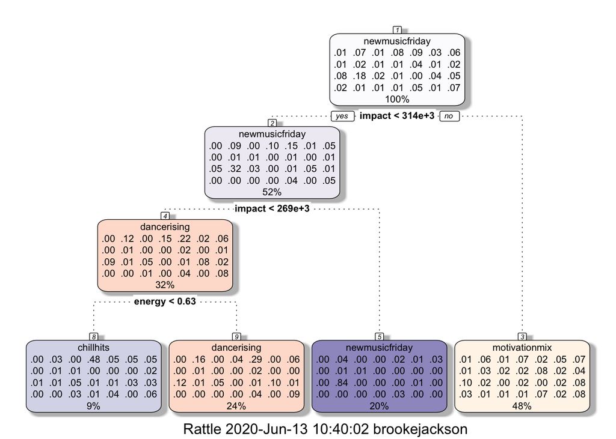

```r
fancyRpartPlot(fit.tree$finalModel)
```

```r
pred.tree <- predict(fit.tree, newdata=present_test)
table(pred.tree,present_test$playlist_name)
```

```
##
## pred.tree        arebe cardio chilledrb chillhits dancerising getturnt
##   arebe              0      0         0         0           0        0
##   cardio             0      0         0         0           0        0
##   chilledrb          0      0         0         0           0        0
##   chillhits          0      1         4        20         116        3
##   dancerising        0     12         0         2           3        5
##   getturnt           0      0         0         0           0        0
##   happyhits          0      0         0         0           0        0
##   hotcountry         0      0         0         0           0        0
##   hotrhythmic        0      0         0         0           0        0
##   intensestudy       0      0         0         0           0        0
##   kpopdaebak         0      0         0         0           0        0
##   mint               0      0         0         0           0        0
##   moodbooster        0      0         0         0           0        0
##   mostnecessary      0      0         0         0           0        0
##   motivationmix     45     46        46       108          51       92
##   newmusicfriday     0      1         0         0           0        0
##   nextnash           0      0         0         0           0        0
##   peacefulpiano      0      0         0         0           0        0
##   popco              0      0         0         0           0        0
##   popremix           0      0         0         0           0        0
##   powerworkout       0      0         0         0           0        0
##   rapcaviar          0      0         0         0           0        0
##   rockthis           0      0         0         0           0        0
##   silksheets         0      0         0         0           0        0
##   sleep              0      0         0         0           0        0
##   teenparty          0      0         0         0           0        0
##   ultindie           0      0         0         0           0        0
##   workout            0      0         0         0           0        0
##
## pred.tree        happyhits hotcountry hotrhythmic intensestudy kpopdaebak mint
##   arebe                  0          0           0            0          0    0
##   cardio                 0          0           0            0          0    0
##   chilledrb              0          0           0            0          0    0
##   chillhits              2          1           2           36          0    1
##   dancerising           16          5           2            0          1    2
##   getturnt               0          0           0            0          0    0
##   happyhits              0          0           0            0          0    0
##   hotcountry             0          0           0            0          0    0
```

[output cut: 95 more lines]

```
##   mostnecessary         0          0     0         0        0       0
##   motivationmix        47         36   204        51      100      56
##   newmusicfriday        0          2     0         0        0       0
##   nextnash              0          0     0         0        0       0
##   peacefulpiano         0          0     0         0        0       0
##   popco                 0          0     0         0        0       0
##   popremix              0          0     0         0        0       0
##   powerworkout          0          0     0         0        0       0
##   rapcaviar             0          0     0         0        0       0
##   rockthis              0          0     0         0        0       0
##   silksheets            0          0     0         0        0       0
##   sleep                 0          0     0         0        0       0
##   teenparty             0          0     0         0        0       0
##   ultindie              0          0     0         0        0       0
##   workout               0          0     0         0        0       0
```

```r
correct <- pred.tree == present_test$playlist_name
summary(correct)
```

```
##    Mode   FALSE    TRUE
## logical    2614     103
```